# SRA_insects_E93_ratios

G.Machaj

7 04 2022

## Load libraries

```r
library(DESeq2)
library(dplyr)
library(ggplot2)
library(Rsubread)
library(ggrepel)
library(edgeR)
library(readr)
```

# Read TPM counts and metadata for PCA

## Blattella germanica, E93, Hemimetabolous

### read data

- Load TPM table

```r
B.germanica_TPM <- read.csv("B.germanica_TPM.csv", row.names = 1)
```

- Load Metdata

```r
Meatdata_ds3exp_B.germanica <- read_delim("B.germanica_metadata.txt",
     delim = "\t", escape_double = FALSE,
     trim_ws = TRUE)
```

- As DF

```r
Meatdata_ds3exp_B.germanica_DF<-as.data.frame(Meatdata_ds3exp_B.germanica)
rownames(Meatdata_ds3exp_B.germanica_DF)<-(Meatdata_ds3exp_B.germanica_DF$Sample)
```

- TPM long format and metadata

```r
library(tidyr)
ds_B.germanica_TPM_long<-B.germanica_TPM %>%
  as.data.frame() %>%
  tibble::rownames_to_column(var = "GeneID") %>%
  pivot_longer(cols=colnames(B.germanica_TPM),names_to="Sample", values_to="TPM") %>%
   dplyr::left_join(Meatdata_ds3exp_B.germanica_DF, by=c("Sample"="Sample"))
```

- E93 expression table

```r
 E93_B.germanica_TPM<-ds_B.germanica_TPM_long %>%
   filter(GeneID=="E93")
E93_B.germanica_TPM
```

```
## # A tibble: 12 × 8
##    GeneID Sample                 TPM Species Metamorphosis SRA   Index Condition
##    <chr>  <chr>                <dbl> <chr>   <chr>         <chr> <chr> <chr>
##  1 E93    SRR5656359_Aligned… 0.381  Blatte… Hemimetabolo… SRR5… embr… embryo
##  2 E93    SRR5656360_Aligned… 0.433  Blatte… Hemimetabolo… SRR5… embr… embryo
##  3 E93    SRR5656361_Aligned… 0.133  Blatte… Hemimetabolo… SRR5… embr… embryo
##  4 E93    SRR5656362_Aligned… 0.270  Blatte… Hemimetabolo… SRR5… embr… embryo
##  5 E93    SRR5656363_Aligned… 0.141  Blatte… Hemimetabolo… SRR5… embr… embryo
##  6 E93    SRR5656364_Aligned… 0.102  Blatte… Hemimetabolo… SRR5… embr… embryo
##  7 E93    SRR5656365_Aligned… 0.0850 Blatte… Hemimetabolo… SRR5… embr… embryo
##  8 E93    SRR5656366_Aligned… 0.148  Blatte… Hemimetabolo… SRR5… embr… embryo
##  9 E93    SRR5656367_Aligned… 0.222  Blatte… Hemimetabolo… SRR5… embr… embryo
## 10 E93    SRR5656368_Aligned… 0.228  Blatte… Hemimetabolo… SRR5… embr… embryo
## 11 E93    SRR6784708_Aligned… 0.756  Blatte… Hemimetabolo… SRR6… nymp… nymph
## 12 E93    SRR6784709_Aligned… 0.631  Blatte… Hemimetabolo… SRR6… nymp… nymph
```

```r
#write.csv(E93_B.germanica_TPM, file = "E93_B.germanica_TPM.csv", row.names=TRUE)
```

## Gryllus bimaculatus, E93 = GBI_04085, Hemimetabolous

### read data

- Load TPM table

```r
G.bimaculatus_TPM <- read.csv("G.bimaculatus_TPM.csv", row.names = 1)
```

- Load Metdata

```r
Meatdata_ds3exp_G.bimaculatus <- read_delim("G.bimaculatus_metadata.txt",
     delim = "\t", escape_double = FALSE,
     trim_ws = TRUE)
```

- As DF

```r
Meatdata_ds3exp_G.bimaculatus_DF<-as.data.frame(Meatdata_ds3exp_G.bimaculatus)
rownames(Meatdata_ds3exp_G.bimaculatus_DF)<-(Meatdata_ds3exp_G.bimaculatus_DF$Sample)
```

- TPM long format and metadata

```r
library(tidyr)
ds_G.bimaculatus_TPM_long<-G.bimaculatus_TPM %>%
  as.data.frame() %>%
  tibble::rownames_to_column(var = "GeneID") %>%
  pivot_longer(cols=colnames(G.bimaculatus_TPM),names_to="Sample", values_to="TPM") %>%
   dplyr::left_join(Meatdata_ds3exp_G.bimaculatus_DF, by=c("Sample"="Sample"))
```

- E93 expression table

```r
 E93_G.bimaculatus_TPM<-ds_G.bimaculatus_TPM_long %>%
   filter(GeneID=="GBI_04085")
E93_G.bimaculatus_TPM
```

```
## # A tibble: 34 × 8
##    GeneID    Sample              TPM Species Metamorphosis SRA   Index Condition
##    <chr>     <chr>             <dbl> <chr>   <chr>         <chr> <chr> <chr>
##  1 GBI_04085 DRR255763_Align… 0.608  Gryllu… Hemimetabolo… DRR2… embr… embryo
##  2 GBI_04085 DRR255764_Align… 1.12   Gryllu… Hemimetabolo… DRR2… embr… embryo
##  3 GBI_04085 DRR255765_Align… 0.0494 Gryllu… Hemimetabolo… DRR2… embr… embryo
##  4 GBI_04085 DRR255766_Align… 0.0557 Gryllu… Hemimetabolo… DRR2… embr… embryo
##  5 GBI_04085 DRR258387_Align… 0      Gryllu… Hemimetabolo… DRR2… embr… embryo
##  6 GBI_04085 DRR258388_Align… 0      Gryllu… Hemimetabolo… DRR2… embr… embryo
##  7 GBI_04085 DRR258389_Align… 0      Gryllu… Hemimetabolo… DRR2… embr… embryo
##  8 GBI_04085 DRR258390_Align… 0      Gryllu… Hemimetabolo… DRR2… embr… embryo
##  9 GBI_04085 DRR258391_Align… 0      Gryllu… Hemimetabolo… DRR2… embr… embryo
## 10 GBI_04085 DRR258392_Align… 0      Gryllu… Hemimetabolo… DRR2… embr… embryo
## # … with 24 more rows
```

```r
#write.csv(E93_G.bimaculatus_TPM, file = "E93_G.bimaculatus_TPM.csv", row.names=TRUE)
```

## Folsomia candida, gene-LOC110851286, Ametabolous

### read data

- Load TPM table

```r
F.candida_TPM <- read.csv("F.candida_TPM.csv", row.names = 1)
```

- Load Metdata

```r
Meatdata_ds3exp_F.candida <- read_delim("F.candida_metadata.txt",
     delim = "\t", escape_double = FALSE,
     trim_ws = TRUE)
```

- As DF

```r
Meatdata_ds3exp_F.candida_DF<-as.data.frame(Meatdata_ds3exp_F.candida)
rownames(Meatdata_ds3exp_F.candida_DF)<-(Meatdata_ds3exp_F.candida_DF$Sample)
```

- TPM long format and metadata

```r
library(tidyr)
ds_F.candida_TPM_long<-F.candida_TPM %>%
  as.data.frame() %>%
  tibble::rownames_to_column(var = "GeneID") %>%
  pivot_longer(cols=colnames(F.candida_TPM),names_to="Sample", values_to="TPM") %>%
   dplyr::left_join(Meatdata_ds3exp_F.candida_DF, by=c("Sample"="Sample"))
```

- E93 expression table

```r
 E93_F.candida_TPM<-ds_F.candida_TPM_long %>%
   filter(GeneID=="gene-LOC110851286")
E93_F.candida_TPM
```

```
## # A tibble: 11 × 8
##    GeneID            Sample      TPM Species Metamorphosis SRA   Index Condition
##    <chr>             <chr>     <dbl> <chr>   <chr>         <chr> <chr> <chr>
##  1 gene-LOC110851286 SRR670… 0.474   Folsom… Ametabolous   SRR6… juve… nymph
##  2 gene-LOC110851286 SRR670… 0.314   Folsom… Ametabolous   SRR6… egg-… embryo
##  3 gene-LOC110851286 SRR670… 1.58    Folsom… Ametabolous   SRR6… egg-… embryo
##  4 gene-LOC110851286 SRR670… 0.128   Folsom… Ametabolous   SRR6… egg-… embryo
##  5 gene-LOC110851286 SRR670… 0.0836  Folsom… Ametabolous   SRR6… egg-… embryo
##  6 gene-LOC110851286 SRR670… 0.00866 Folsom… Ametabolous   SRR6… egg-… embryo
##  7 gene-LOC110851286 SRR670… 0.00865 Folsom… Ametabolous   SRR6… egg-… embryo
##  8 gene-LOC110851286 SRR670… 0.00652 Folsom… Ametabolous   SRR6… egg-… embryo
##  9 gene-LOC110851286 SRR670… 0.0106  Folsom… Ametabolous   SRR6… egg-… embryo
## 10 gene-LOC110851286 SRR670… 0       Folsom… Ametabolous   SRR6… egg-… embryo
## 11 gene-LOC110851286 SRR670… 0.00214 Folsom… Ametabolous   SRR6… egg-… embryo
```

```r
#write.csv(E93_F.candida_TPM, file = "E93_F.candida_TPM.csv", row.names=TRUE)
```

### read data

- Load TPM table

```r
A.pisum_TPM <- read.csv("A.pisum_TPM.csv", row.names = 1)
```

- Load Metdata

```r
Meatdata_ds3exp_A.pisum <- read_delim("A.pisum_metadata.txt",
     delim = "\t", escape_double = FALSE,
     trim_ws = TRUE)
```

- As DF

```r
Meatdata_ds3exp_A.pisum_DF<-as.data.frame(Meatdata_ds3exp_A.pisum)
rownames(Meatdata_ds3exp_A.pisum_DF)<-(Meatdata_ds3exp_A.pisum_DF$Sample)
```

- TPM long format and metadata

```r
library(tidyr)
ds_A.pisum_TPM_long<-A.pisum_TPM %>%
  as.data.frame() %>%
  tibble::rownames_to_column(var = "GeneID") %>%
  pivot_longer(cols=colnames(A.pisum_TPM),names_to="Sample", values_to="TPM") %>%
   dplyr::left_join(Meatdata_ds3exp_A.pisum_DF, by=c("Sample"="Sample"))
```

- E93 expression table

```r
 E93_A.pisum_TPM<-ds_A.pisum_TPM_long %>%
   filter(GeneID=="gene-LOC100161761")
E93_A.pisum_TPM
```

```
## # A tibble: 11 × 8
##    GeneID            Sample      TPM Species Metamorphosis SRA   Index Condition
##    <chr>             <chr>     <dbl> <chr>   <chr>         <chr> <chr> <chr>
##  1 gene-LOC100161761 SRR1136… 0.0644 Acyrth… Neometabolous SRR1… nymp… nymph
##  2 gene-LOC100161761 SRR1136… 0.0641 Acyrth… Neometabolous SRR1… nymp… nymph
##  3 gene-LOC100161761 SRR1136… 0.0673 Acyrth… Neometabolous SRR1… nymp… nymph
##  4 gene-LOC100161761 SRR9877… 0.0804 Acyrth… Neometabolous SRR9… embr… embryo
##  5 gene-LOC100161761 SRR9877… 0.0741 Acyrth… Neometabolous SRR9… embr… embryo
##  6 gene-LOC100161761 SRR9877… 0.0865 Acyrth… Neometabolous SRR9… embr… embryo
##  7 gene-LOC100161761 SRR9877… 0.0581 Acyrth… Neometabolous SRR9… embr… embryo
##  8 gene-LOC100161761 SRR9877… 0.0733 Acyrth… Neometabolous SRR9… embr… embryo
##  9 gene-LOC100161761 SRR9877… 0.0831 Acyrth… Neometabolous SRR9… embr… embryo
## 10 gene-LOC100161761 SRR9877… 0.0768 Acyrth… Neometabolous SRR9… embr… embryo
## 11 gene-LOC100161761 SRR9877… 0.0672 Acyrth… Neometabolous SRR9… embr… embryo
```

```r
#write.csv(E93_A.pisum_TPM, file = "E93_A.pisum_TPM.csv", row.names=TRUE)
```

## Nilaparvata lugens, gene-LOC111052728, Hemimetabolous

### read data

- Load TPM table

```r
N.lugens_TPM <- read.csv("N.lugens_TPM.csv", row.names = 1)
```

- Load Metdata

```r
Meatdata_ds3exp_N.lugens <- read_delim("N.lugens_metadata.txt",
     delim = "\t", escape_double = FALSE,
     trim_ws = TRUE)
```

- As DF

```r
Meatdata_ds3exp_N.lugens_DF<-as.data.frame(Meatdata_ds3exp_N.lugens)
rownames(Meatdata_ds3exp_N.lugens_DF)<-(Meatdata_ds3exp_N.lugens_DF$Sample)
```

- TPM long format and metadata

```r
library(tidyr)
ds_N.lugens_TPM_long<-N.lugens_TPM %>%
  as.data.frame() %>%
  tibble::rownames_to_column(var = "GeneID") %>%
  pivot_longer(cols=colnames(N.lugens_TPM),names_to="Sample", values_to="TPM") %>%
   dplyr::left_join(Meatdata_ds3exp_N.lugens_DF, by=c("Sample"="Sample"))
```

- E93 expression table

```r
 E93_N.lugens_TPM<-ds_N.lugens_TPM_long %>%
   filter(GeneID=="gene-LOC111052728")
E93_N.lugens_TPM
```

```
## # A tibble: 10 × 8
##    GeneID            Sample      TPM Species Metamorphosis SRA   Index Condition
##    <chr>             <chr>     <dbl> <chr>   <chr>         <chr> <chr> <chr>
##  1 gene-LOC111052728 SRR103… 2.94e-1 Nilapa… Hemimetabolo… SRR1… embr… embryo
##  2 gene-LOC111052728 SRR103… 1.77e-1 Nilapa… Hemimetabolo… SRR1… embr… embryo
##  3 gene-LOC111052728 SRR103… 4.04e-2 Nilapa… Hemimetabolo… SRR1… embr… embryo
##  4 gene-LOC111052728 SRR103… 2.28e-2 Nilapa… Hemimetabolo… SRR1… embr… embryo
##  5 gene-LOC111052728 SRR103… 7.10e-4 Nilapa… Hemimetabolo… SRR1… embr… embryo
##  6 gene-LOC111052728 SRR103… 3.89e-3 Nilapa… Hemimetabolo… SRR1… embr… embryo
##  7 gene-LOC111052728 SRR103… 3.85e-2 Nilapa… Hemimetabolo… SRR1… embr… embryo
##  8 gene-LOC111052728 SRR103… 2.53e-2 Nilapa… Hemimetabolo… SRR1… embr… embryo
##  9 gene-LOC111052728 SRR106… 2.74e-1 Nilapa… Hemimetabolo… SRR1… nymp… nymph
## 10 gene-LOC111052728 SRR106… 2.19e-1 Nilapa… Hemimetabolo… SRR1… nymp… nymph
```

```r
#write.csv(E93_N.lugens_TPM, file = "E93_N.lugens_TPM.csv", row.names=TRUE)
```

### read data

- Load TPM table

```r
A.gossypii_TPM <- read.csv("A.gossypii_TPM.csv", row.names = 1)
```

- Load Metdata

```r
Meatdata_ds3exp_A.gossypii <- read_delim("A.gossypii_metadata.txt",
     delim = "\t", escape_double = FALSE,
     trim_ws = TRUE)
```

- As DF

```r
Meatdata_ds3exp_A.gossypii_DF<-as.data.frame(Meatdata_ds3exp_A.gossypii)
rownames(Meatdata_ds3exp_A.gossypii_DF)<-(Meatdata_ds3exp_A.gossypii_DF$Sample)
```

- TPM long format and metadata

```r
library(tidyr)
ds_A.gossypii_TPM_long<-A.gossypii_TPM %>%
  as.data.frame() %>%
  tibble::rownames_to_column(var = "GeneID") %>%
  pivot_longer(cols=colnames(A.gossypii_TPM),names_to="Sample", values_to="TPM") %>%
   dplyr::left_join(Meatdata_ds3exp_A.gossypii_DF, by=c("Sample"="Sample"))
```

- E93 expression table

```r
 E93_A.gossypii_TPM<-ds_A.gossypii_TPM_long %>%
   filter(GeneID=="gene-LOC114128046")
E93_A.gossypii_TPM
```

```
## # A tibble: 6 × 8
##   GeneID            Sample       TPM Species Metamorphosis SRA   Index Condition
##   <chr>             <chr>      <dbl> <chr>   <chr>         <chr> <chr> <chr>
## 1 gene-LOC114128046 SRR109021… 2.26  Aphis … Neometabolous SRR1… nymp… nymph
## 2 gene-LOC114128046 SRR109021… 2.28  Aphis … Neometabolous SRR1… nymp… nymph
## 3 gene-LOC114128046 SRR109021… 2.96  Aphis … Neometabolous SRR1… nymp… nymph
## 4 gene-LOC114128046 SRR289528… 0.872 Aphis … Neometabolous SRR2… embr… embryo
## 5 gene-LOC114128046 SRR289529… 1.27  Aphis … Neometabolous SRR2… embr… embryo
## 6 gene-LOC114128046 SRR289529… 1.34  Aphis … Neometabolous SRR2… embr… embryo
```

```r
#write.csv(E93_A.gossypii_TPM, file = "E93_A.gossypii_TPM.csv", row.names=TRUE)
```

## Cloeon dipterum gene-CLODIP_2_CD15741, Hemimetabolous

### read data

- Load TPM table

```r
C.dipterum_TPM <- read.csv("C.dipterum_TPM.csv", row.names = 1)
```

- Load Metdata

```r
Meatdata_ds3exp_C.dipterum <- read_delim("C.dipterum_metadata.txt",
     delim = "\t", escape_double = FALSE,
     trim_ws = TRUE)
```

- As DF

```r
Meatdata_ds3exp_C.dipterum_DF<-as.data.frame(Meatdata_ds3exp_C.dipterum)
rownames(Meatdata_ds3exp_C.dipterum_DF)<-(Meatdata_ds3exp_C.dipterum_DF$Sample)
```

- TPM long format and metadata

```r
library(tidyr)
ds_C.dipterum_TPM_long<-C.dipterum_TPM %>%
  as.data.frame() %>%
  tibble::rownames_to_column(var = "GeneID") %>%
  pivot_longer(cols=colnames(C.dipterum_TPM),names_to="Sample", values_to="TPM") %>%
   dplyr::left_join(Meatdata_ds3exp_C.dipterum_DF, by=c("Sample"="Sample"))
```

- E93 expression table

```r
 E93_C.dipterum_TPM<-ds_C.dipterum_TPM_long %>%
   filter(GeneID=="gene-CLODIP_2_CD15741")
E93_C.dipterum_TPM
```

```
## # A tibble: 31 × 8
##    GeneID              Sample    TPM Species Metamorphosis SRA   Index Condition
##    <chr>               <chr>   <dbl> <chr>   <chr>         <chr> <chr> <chr>
##  1 gene-CLODIP_2_CD15… ERR37… 0.0181 Cloeon… Hemimetabolo… ERR3… embr… embryo
##  2 gene-CLODIP_2_CD15… ERR37… 0.0571 Cloeon… Hemimetabolo… ERR3… embr… embryo
##  3 gene-CLODIP_2_CD15… ERR37… 0.177  Cloeon… Hemimetabolo… ERR3… embr… embryo
##  4 gene-CLODIP_2_CD15… ERR37… 1.71   Cloeon… Hemimetabolo… ERR3… nymp… nymph
##  5 gene-CLODIP_2_CD15… ERR37… 1.61   Cloeon… Hemimetabolo… ERR3… nymp… nymph
##  6 gene-CLODIP_2_CD15… ERR37… 0.0156 Cloeon… Hemimetabolo… ERR3… embr… embryo
##  7 gene-CLODIP_2_CD15… ERR37… 0.0224 Cloeon… Hemimetabolo… ERR3… embr… embryo
##  8 gene-CLODIP_2_CD15… ERR37… 0.0285 Cloeon… Hemimetabolo… ERR3… embr… embryo
##  9 gene-CLODIP_2_CD15… ERR37… 0.0270 Cloeon… Hemimetabolo… ERR3… embr… embryo
## 10 gene-CLODIP_2_CD15… ERR37… 0.0278 Cloeon… Hemimetabolo… ERR3… embr… embryo
## # … with 21 more rows
```

```r
#write.csv(E93_C.dipterum_TPM, file = "E93_C.dipterum_TPM.csv", row.names=TRUE)
```

## Zootermopsis nevadensis gene-LOC110827285, Hemimetabolous

### read data

- Load TPM table

```r
Z.nevadensis_TPM <- read.csv("Z.nevadensis_TPM.csv", row.names = 1)
```

- Load Metdata

```r
Meatdata_ds3exp_Z.nevadensis <- read_delim("Z.nevadensis_metadata.txt",
     delim = "\t", escape_double = FALSE,
     trim_ws = TRUE)
```

- As DF

```r
Meatdata_ds3exp_Z.nevadensis_DF<-as.data.frame(Meatdata_ds3exp_Z.nevadensis)
rownames(Meatdata_ds3exp_Z.nevadensis_DF)<-(Meatdata_ds3exp_Z.nevadensis_DF$Sample)
```

- TPM long format and metadata

```r
library(tidyr)
ds_Z.nevadensis_TPM_long<-Z.nevadensis_TPM %>%
  as.data.frame() %>%
  tibble::rownames_to_column(var = "GeneID") %>%
  pivot_longer(cols=colnames(Z.nevadensis_TPM),names_to="Sample", values_to="TPM") %>%
   dplyr::left_join(Meatdata_ds3exp_Z.nevadensis_DF, by=c("Sample"="Sample"))
```

- E93 expression table

```r
 E93_Z.nevadensis_TPM<-ds_Z.nevadensis_TPM_long %>%
   filter(GeneID=="gene-LOC110827285")
E93_Z.nevadensis_TPM
```

```
## # A tibble: 3 × 8
##   GeneID            Sample       TPM Species Metamorphosis SRA   Index Condition
##   <chr>             <chr>      <dbl> <chr>   <chr>         <chr> <chr> <chr>
## 1 gene-LOC110827285 SRR116704… 1.98  Zooter… Hemimetabolo… SRR1… nymp… nymph
## 2 gene-LOC110827285 SRR863596… 0.885 Zooter… Hemimetabolo… SRR8… egg   embryo
## 3 gene-LOC110827285 SRR863599… 3.73  Zooter… Hemimetabolo… SRR8… nymp… nymph
```

```r
#write.csv(E93_Z.nevadensis_TPM, file = "E93_Z.nevadensis_TPM.csv", row.names=TRUE)
```

### read data

- Load TPM table

```r
B.tabaci_TPM <- read.csv("B.tabaci_TPM.csv", row.names = 1)
```

- Load Metdata

```r
Meatdata_ds3exp_B.tabaci <- read_delim("B.tabaci_metadata.txt",
     delim = "\t", escape_double = FALSE,
     trim_ws = TRUE)
```

- As DF

```r
Meatdata_ds3exp_B.tabaci_DF<-as.data.frame(Meatdata_ds3exp_B.tabaci)
rownames(Meatdata_ds3exp_B.tabaci_DF)<-(Meatdata_ds3exp_B.tabaci_DF$Sample)
```

- TPM long format and metadata

```r
library(tidyr)
ds_B.tabaci_TPM_long<-B.tabaci_TPM %>%
  as.data.frame() %>%
  tibble::rownames_to_column(var = "GeneID") %>%
  pivot_longer(cols=colnames(B.tabaci_TPM),names_to="Sample", values_to="TPM") %>%
   dplyr::left_join(Meatdata_ds3exp_B.tabaci_DF, by=c("Sample"="Sample"))
```

- E93 expression table

```r
 E93_B.tabaci_TPM<-ds_B.tabaci_TPM_long %>%
   filter(GeneID=="gene-LOC109033008")
E93_B.tabaci_TPM
```

```
## # A tibble: 26 × 8
##    GeneID            Sample      TPM Species Metamorphosis SRA   Index Condition
##    <chr>             <chr>     <dbl> <chr>   <chr>         <chr> <chr> <chr>
##  1 gene-LOC109033008 ERR3653… 0.0292 Bemisi… Neometabolous ERR3… Egg_a embryo
##  2 gene-LOC109033008 ERR3653… 0.0383 Bemisi… Neometabolous ERR3… Egg_a embryo
##  3 gene-LOC109033008 ERR3653… 0.0427 Bemisi… Neometabolous ERR3… Egg_a embryo
##  4 gene-LOC109033008 ERR4373… 0.0406 Bemisi… Neometabolous ERR4… Egg_b embryo
##  5 gene-LOC109033008 ERR4373… 0.0448 Bemisi… Neometabolous ERR4… Egg_b embryo
##  6 gene-LOC109033008 ERR4373… 0.0314 Bemisi… Neometabolous ERR4… Egg_b embryo
##  7 gene-LOC109033008 SRR1764… 0.285  Bemisi… Neometabolous SRR1… BtM_… nymph
##  8 gene-LOC109033008 SRR1764… 0.218  Bemisi… Neometabolous SRR1… BtM_… nymph
##  9 gene-LOC109033008 SRR1764… 0.472  Bemisi… Neometabolous SRR1… BtA_… nymph
## 10 gene-LOC109033008 SRR1764… 0.387  Bemisi… Neometabolous SRR1… Bt_3… nymph
## # … with 16 more rows
```

```r
#write.csv(E93_B.tabaci_TPM, file = "E93_B.tabaci_TPM.csv", row.names=TRUE)
```

### read data

- Load TPM table

```r
D.citri_TPM <- read.csv("D.citri_TPM.csv", row.names = 1)
```

- Load Metdata

```r
Meatdata_ds3exp_D.citri <- read_delim("D.citri_metadata.txt",
     delim = "\t", escape_double = FALSE,
     trim_ws = TRUE)
```

- As DF

```r
Meatdata_ds3exp_D.citri_DF<-as.data.frame(Meatdata_ds3exp_D.citri)
rownames(Meatdata_ds3exp_D.citri_DF)<-(Meatdata_ds3exp_D.citri_DF$Sample)
```

- TPM long format and metadata

```r
library(tidyr)
ds_D.citri_TPM_long<-D.citri_TPM %>%
  as.data.frame() %>%
  tibble::rownames_to_column(var = "GeneID") %>%
  pivot_longer(cols=colnames(D.citri_TPM),names_to="Sample", values_to="TPM") %>%
   dplyr::left_join(Meatdata_ds3exp_D.citri_DF, by=c("Sample"="Sample"))
```

- E93 expression table

```r
 E93_D.citri_TPM<-ds_D.citri_TPM_long %>%
   filter(GeneID=="gene-LOC103516559")
E93_D.citri_TPM
```

```
## # A tibble: 11 × 8
##    GeneID            Sample      TPM Species Metamorphosis SRA   Index Condition
##    <chr>             <chr>     <dbl> <chr>   <chr>         <chr> <chr> <chr>
##  1 gene-LOC103516559 SRR118… 0.00615 Diapho… Neometabolous SRR1… egg   embryo
##  2 gene-LOC103516559 SRR118… 0.00711 Diapho… Neometabolous SRR1… egg   embryo
##  3 gene-LOC103516559 SRR118… 0.00857 Diapho… Neometabolous SRR1… egg   embryo
##  4 gene-LOC103516559 SRR125… 0.104   Diapho… Neometabolous SRR1… nymp… nymph
##  5 gene-LOC103516559 SRR125… 0.0868  Diapho… Neometabolous SRR1… nymp… nymph
##  6 gene-LOC103516559 SRR169… 0.247   Diapho… Neometabolous SRR1… nymp… nymph
##  7 gene-LOC103516559 SRR169… 0.189   Diapho… Neometabolous SRR1… nymp… nymph
##  8 gene-LOC103516559 SRR169… 0.233   Diapho… Neometabolous SRR1… nymp… nymph
##  9 gene-LOC103516559 SRR169… 0.145   Diapho… Neometabolous SRR1… nymp… nymph
## 10 gene-LOC103516559 SRR169… 0.197   Diapho… Neometabolous SRR1… nymp… nymph
## 11 gene-LOC103516559 SRR169… 0.185   Diapho… Neometabolous SRR1… nymp… nymph
```

```r
#write.csv(E93_D.citri_TPM, file = "E93_D.citri_TPM.csv", row.names=TRUE)
```

## Culex quinquefasciatus gene-LOC6046300, Holometabolous

### read data

- Load TPM table

```r
C.quinquefasciatus_TPM <- read.csv("C.quin_TPM.csv", row.names = 1)
```

- Load Metdata

```r
Meatdata_ds3exp_C.quinquefasciatus <- read_delim("C.quinquefasciatus_metadata.txt",
     delim = "\t", escape_double = FALSE,
     trim_ws = TRUE)
```

- As DF

```r
Meatdata_ds3exp_C.quinquefasciatus_DF<-as.data.frame(Meatdata_ds3exp_C.quinquefasciatus)
rownames(Meatdata_ds3exp_C.quinquefasciatus_DF)<-(Meatdata_ds3exp_C.quinquefasciatus_DF$Sample)
```

- TPM long format and metadata

```r
library(tidyr)
ds_C.quinquefasciatus_TPM_long<-C.quinquefasciatus_TPM %>%
  as.data.frame() %>%
  tibble::rownames_to_column(var = "GeneID") %>%
  pivot_longer(cols=colnames(C.quinquefasciatus_TPM),names_to="Sample", values_to="TPM") %>%
   dplyr::left_join(Meatdata_ds3exp_C.quinquefasciatus_DF, by=c("Sample"="Sample"))
```

- E93 expression table

```r
 E93_C.quinquefasciatus_TPM<-ds_C.quinquefasciatus_TPM_long %>%
   filter(GeneID=="gene-LOC6046300")
E93_C.quinquefasciatus_TPM
```

```
## # A tibble: 7 × 8
##   GeneID          Sample         TPM Species Metamorphosis SRA   Index Condition
##   <chr>           <chr>        <dbl> <chr>   <chr>         <chr> <chr> <chr>
## 1 gene-LOC6046300 SRR407543… 2.02    Culex … Holometabolo… SRR4… pupa  pupa
## 2 gene-LOC6046300 SRR872986… 0.00441 Culex … Holometabolo… SRR8… embr… embryo
## 3 gene-LOC6046300 SRR872986… 0.00249 Culex … Holometabolo… SRR8… embr… embryo
## 4 gene-LOC6046300 SRR872986… 0.00298 Culex … Holometabolo… SRR8… embr… embryo
## 5 gene-LOC6046300 SRR872986… 0.00212 Culex … Holometabolo… SRR8… embr… embryo
## 6 gene-LOC6046300 SRR872986… 0.00343 Culex … Holometabolo… SRR8… embr… embryo
## 7 gene-LOC6046300 SRR872987… 0.00409 Culex … Holometabolo… SRR8… embr… embryo
```

```r
#write.csv(E93_C.quinquefasciatus_TPM, file = "E93_C.quinquefasciatus_TPM.csv", row.names=TRUE)
```

## Zeugodacus cucurbitae gene-LOC105215468, Holometabolous

### read data

- Load TPM table

```r
Z.cucurbitae_TPM <- read.csv("Z.cucurbitae_TPM.csv", row.names = 1)
```

- Load Metdata

```r
Meatdata_ds3exp_Z.cucurbitae <- read_delim("Z.cucurbitae_metadata.txt",
     delim = "\t", escape_double = FALSE,
     trim_ws = TRUE)
```

- As DF

```r
Meatdata_ds3exp_Z.cucurbitae_DF<-as.data.frame(Meatdata_ds3exp_Z.cucurbitae)
rownames(Meatdata_ds3exp_Z.cucurbitae_DF)<-(Meatdata_ds3exp_Z.cucurbitae_DF$Sample)
```

- TPM long format and metadata

```r
library(tidyr)
ds_Z.cucurbitae_TPM_long<-Z.cucurbitae_TPM %>%
  as.data.frame() %>%
  tibble::rownames_to_column(var = "GeneID") %>%
  pivot_longer(cols=colnames(Z.cucurbitae_TPM),names_to="Sample", values_to="TPM") %>%
   dplyr::left_join(Meatdata_ds3exp_Z.cucurbitae_DF, by=c("Sample"="Sample"))
```

- E93 expression table

```r
 E93_Z.cucurbitae_TPM<-ds_Z.cucurbitae_TPM_long %>%
   filter(GeneID=="gene-LOC105215468")
E93_Z.cucurbitae_TPM
```

```
## # A tibble: 29 × 8
##    GeneID            Sample      TPM Species Metamorphosis SRA   Index Condition
##    <chr>             <chr>     <dbl> <chr>   <chr>         <chr> <chr> <chr>
##  1 gene-LOC105215468 ERR4026… 0.0101 Zeugod… Holometabolo… ERR4… pupa… pupa
##  2 gene-LOC105215468 ERR4026… 0.0134 Zeugod… Holometabolo… ERR4… pupa… pupa
##  3 gene-LOC105215468 ERR4026… 0.296  Zeugod… Holometabolo… ERR4… pupa… pupa
##  4 gene-LOC105215468 ERR4026… 0.298  Zeugod… Holometabolo… ERR4… pupa… pupa
##  5 gene-LOC105215468 ERR4026… 0.324  Zeugod… Holometabolo… ERR4… pupa… pupa
##  6 gene-LOC105215468 ERR4026… 0.325  Zeugod… Holometabolo… ERR4… pupa… pupa
##  7 gene-LOC105215468 ERR4026… 0.304  Zeugod… Holometabolo… ERR4… pupa… pupa
##  8 gene-LOC105215468 ERR4026… 0.287  Zeugod… Holometabolo… ERR4… pupa… pupa
##  9 gene-LOC105215468 ERR4026… 0.275  Zeugod… Holometabolo… ERR4… pupa… pupa
## 10 gene-LOC105215468 ERR4026… 0.0121 Zeugod… Holometabolo… ERR4… pupa… pupa
## # … with 19 more rows
```

```r
#write.csv(E93_Z.cucurbitae_TPM, file = "E93_Z.cucurbitae_TPM.csv", row.names=TRUE)
```

## Camponotus floridanus gene-LOC105255462, Holometabolous

### read data

- Load TPM table

```r
C.floridanus_TPM <- read.csv("C.flori_TPM.csv", row.names = 1)
```

- Load Metdata

```r
Meatdata_ds3exp_C.floridanus <- read_delim("C.floridanus_metadata.txt",
     delim = "\t", escape_double = FALSE,
     trim_ws = TRUE)
```

- As DF

```r
Meatdata_ds3exp_C.floridanus_DF<-as.data.frame(Meatdata_ds3exp_C.floridanus)
rownames(Meatdata_ds3exp_C.floridanus_DF)<-(Meatdata_ds3exp_C.floridanus_DF$Sample)
```

- TPM long format and metadata

```r
library(tidyr)
ds_C.floridanus_TPM_long<-C.floridanus_TPM %>%
  as.data.frame() %>%
  tibble::rownames_to_column(var = "GeneID") %>%
  pivot_longer(cols=colnames(C.floridanus_TPM),names_to="Sample", values_to="TPM") %>%
   dplyr::left_join(Meatdata_ds3exp_C.floridanus_DF, by=c("Sample"="Sample"))
```

- E93 expression table

```r
 E93_C.floridanus_TPM<-ds_C.floridanus_TPM_long %>%
   filter(GeneID=="gene-LOC105255462")
E93_C.floridanus_TPM
```

```
## # A tibble: 9 × 8
##   GeneID            Sample       TPM Species Metamorphosis SRA   Index Condition
##   <chr>             <chr>      <dbl> <chr>   <chr>         <chr> <chr> <chr>
## 1 gene-LOC105255462 SRR59314… 0.0370 Campon… Holometabolo… SRR5… embr… embryo
## 2 gene-LOC105255462 SRR59314… 0.0183 Campon… Holometabolo… SRR5… embr… embryo
## 3 gene-LOC105255462 SRR59314… 0.348  Campon… Holometabolo… SRR5… pupa… pupa
## 4 gene-LOC105255462 SRR59314… 0.250  Campon… Holometabolo… SRR5… pupa… pupa
## 5 gene-LOC105255462 SRR59314… 2.42   Campon… Holometabolo… SRR5… pupa… pupa
## 6 gene-LOC105255462 SRR59314… 1.61   Campon… Holometabolo… SRR5… pupa… pupa
## 7 gene-LOC105255462 SRR59314… 0.792  Campon… Holometabolo… SRR5… pupa… pupa
## 8 gene-LOC105255462 SRR59314… 0.790  Campon… Holometabolo… SRR5… pupa… pupa
## 9 gene-LOC105255462 SRR05974… 0.352  Campon… Holometabolo… SRR0… egg   embryo
```

```r
#write.csv(E93_C.floridanus_TPM, file = "E93_C.floridanus_TPM.csv", row.names=TRUE)
```

## Apis mellifera gene-Mblk-1, Holometabolous

### read data

- Load TPM table

```r
A.mellifera_TPM <- read.csv("A.mellifera_TPM.csv", row.names = 1)
```

- Load Metdata

```r
Meatdata_ds3exp_A.mellifera <- read_delim("A.mellifera_metadata.txt",
     delim = "\t", escape_double = FALSE,
     trim_ws = TRUE)
```

- As DF

```r
Meatdata_ds3exp_A.mellifera_DF<-as.data.frame(Meatdata_ds3exp_A.mellifera)
rownames(Meatdata_ds3exp_A.mellifera_DF)<-(Meatdata_ds3exp_A.mellifera_DF$Sample)
```

- TPM long format and metadata

```r
library(tidyr)
ds_A.mellifera_TPM_long<-A.mellifera_TPM %>%
  as.data.frame() %>%
  tibble::rownames_to_column(var = "GeneID") %>%
  pivot_longer(cols=colnames(A.mellifera_TPM),names_to="Sample", values_to="TPM") %>%
   dplyr::left_join(Meatdata_ds3exp_A.mellifera_DF, by=c("Sample"="Sample"))
```

- E93 expression table

```r
 E93_A.mellifera_TPM<-ds_A.mellifera_TPM_long %>%
   filter(GeneID=="gene-Mblk-1")
E93_A.mellifera_TPM
```

```
## # A tibble: 82 × 8
##    GeneID      Sample            TPM Species Metamorphosis SRA   Index Condition
##    <chr>       <chr>           <dbl> <chr>   <chr>         <chr> <chr> <chr>
##  1 gene-Mblk-1 ERR528753_Alig… 0.664 Apis m… Holometabolo… ERR5… pupa… pupa
##  2 gene-Mblk-1 ERR528754_Alig… 0.453 Apis m… Holometabolo… ERR5… pupa… pupa
##  3 gene-Mblk-1 SRR11634539_Al… 1.09  Apis m… Holometabolo… SRR1… pupa… pupa
##  4 gene-Mblk-1 SRR11634540_Al… 1.58  Apis m… Holometabolo… SRR1… pupa… pupa
##  5 gene-Mblk-1 SRR11634541_Al… 0.895 Apis m… Holometabolo… SRR1… pupa… pupa
##  6 gene-Mblk-1 SRR11634542_Al… 0.705 Apis m… Holometabolo… SRR1… pupa… pupa
##  7 gene-Mblk-1 SRR11634543_Al… 1.02  Apis m… Holometabolo… SRR1… pupa… pupa
##  8 gene-Mblk-1 SRR11634544_Al… 1.02  Apis m… Holometabolo… SRR1… pupa… pupa
##  9 gene-Mblk-1 SRR15258477_Al… 0.369 Apis m… Holometabolo… SRR1… pupa… pupa
## 10 gene-Mblk-1 SRR15258478_Al… 0.337 Apis m… Holometabolo… SRR1… pupa… pupa
## # … with 72 more rows
```

```r
#write.csv(E93_A.mellifera_TPM, file = "E93_A.mellifera_TPM.csv", row.names=TRUE)
```

## Tribolium castaneum gene-LOC655012, Holometabolous

### read data

- Load TPM table

```r
T.castaneum_TPM <- read.csv("T.castaneum_TPM.csv", row.names = 1)
```

- Load Metdata

```r
Meatdata_ds3exp_T.castaneum <- read_delim("T.castaneum_metadata.txt",
     delim = "\t", escape_double = FALSE,
     trim_ws = TRUE)
```

- As DF

```r
Meatdata_ds3exp_T.castaneum_DF<-as.data.frame(Meatdata_ds3exp_T.castaneum)
rownames(Meatdata_ds3exp_T.castaneum_DF)<-(Meatdata_ds3exp_T.castaneum_DF$Sample)
```

- TPM long format and metadata

```r
library(tidyr)
ds_T.castaneum_TPM_long<-T.castaneum_TPM %>%
  as.data.frame() %>%
  tibble::rownames_to_column(var = "GeneID") %>%
  pivot_longer(cols=colnames(T.castaneum_TPM),names_to="Sample", values_to="TPM") %>%
   dplyr::left_join(Meatdata_ds3exp_T.castaneum_DF, by=c("Sample"="Sample"))
```

- E93 expression table

```r
 E93_T.castaneum_TPM<-ds_T.castaneum_TPM_long %>%
   filter(GeneID=="gene-LOC655012")
E93_T.castaneum_TPM
```

```
## # A tibble: 85 × 8
##    GeneID         Sample         TPM Species Metamorphosis SRA   Index Condition
##    <chr>          <chr>        <dbl> <chr>   <chr>         <chr> <chr> <chr>
##  1 gene-LOC655012 SRR103970… 0.0444  Tribol… Holometabolo… SRR1… egg_… embryo
##  2 gene-LOC655012 SRR110678… 0.0125  Tribol… Holometabolo… SRR1… egg_… embryo
##  3 gene-LOC655012 SRR110678… 0.0103  Tribol… Holometabolo… SRR1… egg_… embryo
##  4 gene-LOC655012 SRR110679… 0.00684 Tribol… Holometabolo… SRR1… egg_… embryo
##  5 gene-LOC655012 SRR110679… 0.00644 Tribol… Holometabolo… SRR1… egg_… embryo
##  6 gene-LOC655012 SRR110679… 0.0169  Tribol… Holometabolo… SRR1… egg_… embryo
##  7 gene-LOC655012 SRR110679… 0.0135  Tribol… Holometabolo… SRR1… egg_… embryo
##  8 gene-LOC655012 SRR110679… 0.0123  Tribol… Holometabolo… SRR1… egg_… embryo
##  9 gene-LOC655012 SRR110679… 0.0263  Tribol… Holometabolo… SRR1… egg_… embryo
## 10 gene-LOC655012 SRR110679… 0.0147  Tribol… Holometabolo… SRR1… egg_… embryo
## # … with 75 more rows
```

```r
#write.csv(E93_T.castaneum_TPM, file = "E93_T.castaneum_TPM.csv", row.names=TRUE)
```

## Harpegnathos saltator gene-LOC105183699, Holometabolous

### read data

- Load TPM table

```r
H.saltator_TPM <- read.csv("H.salt_TPM.csv", row.names = 1)
```

- Load Metdata

```r
Meatdata_ds3exp_H.saltator <- read_delim("H.saltator_metadata.txt",
     delim = "\t", escape_double = FALSE,
     trim_ws = TRUE)
```

- As DF

```r
Meatdata_ds3exp_H.saltator_DF<-as.data.frame(Meatdata_ds3exp_H.saltator)
rownames(Meatdata_ds3exp_H.saltator_DF)<-(Meatdata_ds3exp_H.saltator_DF$Sample)
```

- TPM long format and metadata

```r
library(tidyr)
ds_H.saltator_TPM_long<-H.saltator_TPM %>%
  as.data.frame() %>%
  tibble::rownames_to_column(var = "GeneID") %>%
  pivot_longer(cols=colnames(H.saltator_TPM),names_to="Sample", values_to="TPM") %>%
   dplyr::left_join(Meatdata_ds3exp_H.saltator_DF, by=c("Sample"="Sample"))
```

- E93 expression table

```r
 E93_H.saltator_TPM<-ds_H.saltator_TPM_long %>%
   filter(GeneID=="gene-LOC105183699")
E93_H.saltator_TPM
```

```
## # A tibble: 7 × 8
##   GeneID            Sample       TPM Species Metamorphosis SRA   Index Condition
##   <chr>             <chr>      <dbl> <chr>   <chr>         <chr> <chr> <chr>
## 1 gene-LOC105183699 SRR59314… 0.0871 Harpeg… Holometabolo… SRR5… embr… embryo
## 2 gene-LOC105183699 SRR59314… 0.195  Harpeg… Holometabolo… SRR5… embr… embryo
## 3 gene-LOC105183699 SRR59314… 2.80   Harpeg… Holometabolo… SRR5… pupa… pupa
## 4 gene-LOC105183699 SRR59314… 1.74   Harpeg… Holometabolo… SRR5… pupa… pupa
## 5 gene-LOC105183699 SRR59314… 2.77   Harpeg… Holometabolo… SRR5… pupa… pupa
## 6 gene-LOC105183699 SRR59314… 3.79   Harpeg… Holometabolo… SRR5… pupa… pupa
## 7 gene-LOC105183699 SRR05974… 0.855  Harpeg… Holometabolo… SRR0… egg   embryo
```

```r
#write.csv(E93_H.saltator_TPM, file = "E93_H.saltator_TPM.csv", row.names=TRUE)
```

## Manduca sexta gene-LOC115453157, Holometabolous

### read data

- Load TPM table

```r
M.sexta_TPM <- read.csv("M.sexta_TPM.csv", row.names = 1)
```

- Load Metdata

```r
Meatdata_ds3exp_M.sexta <- read_delim("M.sexta_metadata.txt",
     delim = "\t", escape_double = FALSE,
     trim_ws = TRUE)
```

- As DF

```r
Meatdata_ds3exp_M.sexta_DF<-as.data.frame(Meatdata_ds3exp_M.sexta)
rownames(Meatdata_ds3exp_M.sexta_DF)<-(Meatdata_ds3exp_M.sexta_DF$Sample)
```

- TPM long format and metadata

```r
library(tidyr)
ds_M.sexta_TPM_long<-M.sexta_TPM %>%
  as.data.frame() %>%
  tibble::rownames_to_column(var = "GeneID") %>%
  pivot_longer(cols=colnames(M.sexta_TPM),names_to="Sample", values_to="TPM") %>%
   dplyr::left_join(Meatdata_ds3exp_M.sexta_DF, by=c("Sample"="Sample"))
```

- E93 expression table

```r
 E93_M.sexta_TPM<-ds_M.sexta_TPM_long %>%
   filter(GeneID=="gene-LOC115453157")
E93_M.sexta_TPM
```

```
## # A tibble: 9 × 8
##   GeneID            Sample       TPM Species Metamorphosis SRA   Index Condition
##   <chr>             <chr>      <dbl> <chr>   <chr>         <chr> <chr> <chr>
## 1 gene-LOC115453157 SRR1096… 0.0672  Manduc… Holometabolo… SRR1… embr… embryo
## 2 gene-LOC115453157 SRR1096… 0.00799 Manduc… Holometabolo… SRR1… embr… embryo
## 3 gene-LOC115453157 SRR1096… 0.0958  Manduc… Holometabolo… SRR1… embr… embryo
## 4 gene-LOC115453157 SRR2659… 0.825   Manduc… Holometabolo… SRR2… pupa… pupa
## 5 gene-LOC115453157 SRR1096… 0.0162  Manduc… Holometabolo… SRR1… embr… embryo
## 6 gene-LOC115453157 SRR1096… 0.00519 Manduc… Holometabolo… SRR1… embr… embryo
## 7 gene-LOC115453157 SRR1096… 0.0178  Manduc… Holometabolo… SRR1… embr… embryo
## 8 gene-LOC115453157 SRR2659… 0.0306  Manduc… Holometabolo… SRR2… egg   embryo
## 9 gene-LOC115453157 SRR2659… 0.00623 Manduc… Holometabolo… SRR2… egg_… embryo
```

```r
#write.csv(E93_M.sexta_TPM, file = "E93_M.sexta_TPM.csv", row.names=TRUE)
```

## Plutella xylostella gene-LOC105385744, Holometabolous

### read data

- Load TPM table

```r
P.xylostella_TPM <- read.csv("P.xylostella_TPM.csv", row.names = 1)
```

- Load Metdata

```r
Meatdata_ds3exp_P.xylostella <- read_delim("P.xylostella_metadata.txt",
     delim = "\t", escape_double = FALSE,
     trim_ws = TRUE)
```

- As DF

```r
Meatdata_ds3exp_P.xylostella_DF<-as.data.frame(Meatdata_ds3exp_P.xylostella)
rownames(Meatdata_ds3exp_P.xylostella_DF)<-(Meatdata_ds3exp_P.xylostella_DF$Sample)
```

- TPM long format and metadata

```r
library(tidyr)
ds_P.xylostella_TPM_long<-P.xylostella_TPM %>%
  as.data.frame() %>%
  tibble::rownames_to_column(var = "GeneID") %>%
  pivot_longer(cols=colnames(P.xylostella_TPM),names_to="Sample", values_to="TPM") %>%
   dplyr::left_join(Meatdata_ds3exp_P.xylostella_DF, by=c("Sample"="Sample"))
```

- E93 expression table

```r
 E93_P.xylostella_TPM<-ds_P.xylostella_TPM_long %>%
   filter(GeneID=="gene-LOC105385744")
E93_P.xylostella_TPM
```

```
## # A tibble: 2 × 8
##   GeneID            Sample       TPM Species Metamorphosis SRA   Index Condition
##   <chr>             <chr>      <dbl> <chr>   <chr>         <chr> <chr> <chr>
## 1 gene-LOC105385744 SRR179062… 0.399 Plutel… Holometabolo… SRR1… egg   embryo
## 2 gene-LOC105385744 SRR179509… 5.72  Plutel… Holometabolo… SRR1… pupa  pupa
```

```r
#write.csv(E93_P.xylostella_TPM, file = "E93_P.xylostella_TPM.csv", row.names=TRUE)
```

## Bombyx mori gene-LOC101737038, Holometabolous

### read data

- Load TPM table

```r
B.mori_TPM <- read.csv("B.mori_TPM.csv", row.names = 1)
```

- Load Metdata

```r
Meatdata_ds3exp_B.mori <- read_delim("B.mori_metadata.txt",
     delim = "\t", escape_double = FALSE,
     trim_ws = TRUE)
```

- As DF

```r
Meatdata_ds3exp_B.mori_DF<-as.data.frame(Meatdata_ds3exp_B.mori)
rownames(Meatdata_ds3exp_B.mori_DF)<-(Meatdata_ds3exp_B.mori_DF$Sample)
```

- TPM long format and metadata

```r
library(tidyr)
ds_B.mori_TPM_long<-B.mori_TPM %>%
  as.data.frame() %>%
  tibble::rownames_to_column(var = "GeneID") %>%
  pivot_longer(cols=colnames(B.mori_TPM),names_to="Sample", values_to="TPM") %>%
   dplyr::left_join(Meatdata_ds3exp_B.mori_DF, by=c("Sample"="Sample"))
```

- E93 expression table

```r
 E93_B.mori_TPM<-ds_B.mori_TPM_long %>%
   filter(GeneID=="gene-LOC101737038")
E93_B.mori_TPM
```

```
## # A tibble: 65 × 8
##    GeneID            Sample      TPM Species Metamorphosis SRA   Index Condition
##    <chr>             <chr>     <dbl> <chr>   <chr>         <chr> <chr> <chr>
##  1 gene-LOC101737038 SRR1003… 0.0816 Bombyx… Holometabolo… SRR1… pupa… pupa
##  2 gene-LOC101737038 SRR1003… 0.0736 Bombyx… Holometabolo… SRR1… pupa… pupa
##  3 gene-LOC101737038 SRR1003… 0.0862 Bombyx… Holometabolo… SRR1… pupa… pupa
##  4 gene-LOC101737038 SRR1003… 0.0980 Bombyx… Holometabolo… SRR1… pupa… pupa
##  5 gene-LOC101737038 SRR1003… 0.0649 Bombyx… Holometabolo… SRR1… pupa… pupa
##  6 gene-LOC101737038 SRR1003… 0.0595 Bombyx… Holometabolo… SRR1… pupa… pupa
##  7 gene-LOC101737038 SRR1003… 0.0673 Bombyx… Holometabolo… SRR1… pupa… pupa
##  8 gene-LOC101737038 SRR1003… 0.0602 Bombyx… Holometabolo… SRR1… pupa… pupa
##  9 gene-LOC101737038 SRR1003… 0.0774 Bombyx… Holometabolo… SRR1… pupa… pupa
## 10 gene-LOC101737038 SRR1014… 0.0156 Bombyx… Holometabolo… SRR1… egg_… embryo
## # … with 55 more rows
```

```r
#write.csv(E93_B.mori_TPM, file = "E93_B.mori_TPM.csv", row.names=TRUE)
```

## Leptopilina heterotoma gene-LOC122503059, Holometabolous

### read data

- Load TPM table

```r
L.heterotoma_TPM <- read.csv("L.heterotoma_TPM.csv", row.names = 1)
```

- Load Metdata

```r
Meatdata_ds3exp_L.heterotoma <- read_delim("L.heterotoma_metadata.txt",
     delim = "\t", escape_double = FALSE,
     trim_ws = TRUE)
```

- As DF

```r
Meatdata_ds3exp_L.heterotoma_DF<-as.data.frame(Meatdata_ds3exp_L.heterotoma)
rownames(Meatdata_ds3exp_L.heterotoma_DF)<-(Meatdata_ds3exp_L.heterotoma_DF$Sample)
```

- TPM long format and metadata

```r
library(tidyr)
ds_L.heterotoma_TPM_long<-L.heterotoma_TPM %>%
  as.data.frame() %>%
  tibble::rownames_to_column(var = "GeneID") %>%
  pivot_longer(cols=colnames(L.heterotoma_TPM),names_to="Sample", values_to="TPM") %>%
   dplyr::left_join(Meatdata_ds3exp_L.heterotoma_DF, by=c("Sample"="Sample"))
```

- E93 expression table

```r
 E93_L.heterotoma_TPM<-ds_L.heterotoma_TPM_long %>%
   filter(GeneID=="gene-LOC122503059")
E93_L.heterotoma_TPM
```

```
## # A tibble: 4 × 8
##   GeneID            Sample       TPM Species Metamorphosis SRA   Index Condition
##   <chr>             <chr>      <dbl> <chr>   <chr>         <chr> <chr> <chr>
## 1 gene-LOC122503059 SRR13005… 0.0495 Leptop… Holometabolo… SRR1… pupa… pupa
## 2 gene-LOC122503059 SRR13005… 0.0518 Leptop… Holometabolo… SRR1… pupa… pupa
## 3 gene-LOC122503059 SRR13005… 0.138  Leptop… Holometabolo… SRR1… pupa… pupa
## 4 gene-LOC122503059 SRR13005… 0.0124 Leptop… Holometabolo… SRR1… egg   embryo
```

```r
#write.csv(E93_L.heterotoma_TPM, file = "E93_L.heterotoma_TPM.csv", row.names=TRUE)
```

## Odontomachus brunneus gene-LOC116848284, Holometabolous

### read data

- Load TPM table

```r
O.brunneus_TPM <- read.csv("O.brunneus_TPM.csv", row.names = 1)
```

- Load Metdata

```r
Meatdata_ds3exp_O.brunneus <- read_delim("O.brunneus_metadata.txt",
     delim = "\t", escape_double = FALSE,
     trim_ws = TRUE)
```

- As DF

```r
Meatdata_ds3exp_O.brunneus_DF<-as.data.frame(Meatdata_ds3exp_O.brunneus)
rownames(Meatdata_ds3exp_O.brunneus_DF)<-(Meatdata_ds3exp_O.brunneus_DF$Sample)
```

- TPM long format and metadata

```r
library(tidyr)
ds_O.brunneus_TPM_long<-O.brunneus_TPM %>%
  as.data.frame() %>%
  tibble::rownames_to_column(var = "GeneID") %>%
  pivot_longer(cols=colnames(O.brunneus_TPM),names_to="Sample", values_to="TPM") %>%
   dplyr::left_join(Meatdata_ds3exp_O.brunneus_DF, by=c("Sample"="Sample"))
```

- E93 expression table

```r
 E93_O.brunneus_TPM<-ds_O.brunneus_TPM_long %>%
   filter(GeneID=="gene-LOC116848284")
E93_O.brunneus_TPM
```

```
## # A tibble: 4 × 8
##   GeneID            Sample       TPM Species Metamorphosis SRA   Index Condition
##   <chr>             <chr>      <dbl> <chr>   <chr>         <chr> <chr> <chr>
## 1 gene-LOC116848284 SRR69840… 0.0163 Odonto… Holometabolo… SRR6… egg   embryo
## 2 gene-LOC116848284 SRR69840… 0.156  Odonto… Holometabolo… SRR6… pupa  pupa
## 3 gene-LOC116848284 SRR69840… 0.0179 Odonto… Holometabolo… SRR6… egg   embryo
## 4 gene-LOC116848284 SRR69840… 0.0139 Odonto… Holometabolo… SRR6… egg   embryo
```

```r
#write.csv(E93_O.brunneus_TPM, file = "E93_O.brunneus_TPM.csv", row.names=TRUE)
```

## Anopheles stephensi gene-LOC118503280, Holometabolous

### read data

- Load TPM table

```r
A.stephensi_TPM <- read.csv("A.steph_TPM.csv", row.names = 1)
```

- Load Metdata

```r
Meatdata_ds3exp_A.stephensi <- read_delim("A.stephensi_metadata.txt",
     delim = "\t", escape_double = FALSE,
     trim_ws = TRUE)
```

- As DF

```r
Meatdata_ds3exp_A.stephensi_DF<-as.data.frame(Meatdata_ds3exp_A.stephensi)
rownames(Meatdata_ds3exp_A.stephensi_DF)<-(Meatdata_ds3exp_A.stephensi_DF$Sample)
```

- TPM long format and metadata

```r
library(tidyr)
ds_A.stephensi_TPM_long<-A.stephensi_TPM %>%
  as.data.frame() %>%
  tibble::rownames_to_column(var = "GeneID") %>%
  pivot_longer(cols=colnames(A.stephensi_TPM),names_to="Sample", values_to="TPM") %>%
   dplyr::left_join(Meatdata_ds3exp_A.stephensi_DF, by=c("Sample"="Sample"))
```

- E93 expression table

```r
 E93_A.stephensi_TPM<-ds_A.stephensi_TPM_long %>%
   filter(GeneID=="gene-LOC118503280")
E93_A.stephensi_TPM
```

```
## # A tibble: 4 × 8
##   GeneID            Sample       TPM Species Metamorphosis SRA   Index Condition
##   <chr>             <chr>      <dbl> <chr>   <chr>         <chr> <chr> <chr>
## 1 gene-LOC118503280 SRR51530… 0.0355 Anophe… Holometabolo… SRR5… embr… embryo
## 2 gene-LOC118503280 SRR51530… 1.30   Anophe… Holometabolo… SRR5… pupa  pupa
## 3 gene-LOC118503280 SRR51531… 0.296  Anophe… Holometabolo… SRR5… embr… embryo
## 4 gene-LOC118503280 SRR51534… 0.309  Anophe… Holometabolo… SRR5… embr… embryo
```

```r
#write.csv(E93_A.stephensi_TPM, file = "E93_A.stephensi_TPM.csv", row.names=TRUE)
```

## Monomorium pharaonis gene-LOC105832848, Holometabolous

### read data

- Load TPM table

```r
M.pharaonis_TPM <- read.csv("M.pharaonis_TPM.csv", row.names = 1)
```

- Load Metdata

```r
Meatdata_ds3exp_M.pharaonis <- read_delim("M.pharaonis_metadata.txt",
     delim = "\t", escape_double = FALSE,
     trim_ws = TRUE)
```

- As DF

```r
Meatdata_ds3exp_M.pharaonis_DF<-as.data.frame(Meatdata_ds3exp_M.pharaonis)
rownames(Meatdata_ds3exp_M.pharaonis_DF)<-(Meatdata_ds3exp_M.pharaonis_DF$Sample)
```

- TPM long format and metadata

```r
library(tidyr)
ds_M.pharaonis_TPM_long<-M.pharaonis_TPM %>%
  as.data.frame() %>%
  tibble::rownames_to_column(var = "GeneID") %>%
  pivot_longer(cols=colnames(M.pharaonis_TPM),names_to="Sample", values_to="TPM") %>%
   dplyr::left_join(Meatdata_ds3exp_M.pharaonis_DF, by=c("Sample"="Sample"))
```

- E93 expression table

```r
 E93_M.pharaonis_TPM<-ds_M.pharaonis_TPM_long %>%
   filter(GeneID=="gene-LOC105832848")
E93_M.pharaonis_TPM
```

```
## # A tibble: 15 × 8
##    GeneID            Sample      TPM Species Metamorphosis SRA   Index Condition
##    <chr>             <chr>     <dbl> <chr>   <chr>         <chr> <chr> <chr>
##  1 gene-LOC105832848 SRR970… 3.69e-2 Monomo… Holometabolo… SRR9… pupa… pupa
##  2 gene-LOC105832848 SRR970… 6.56e-2 Monomo… Holometabolo… SRR9… pupa… pupa
##  3 gene-LOC105832848 SRR970… 5.71e-2 Monomo… Holometabolo… SRR9… pupa… pupa
##  4 gene-LOC105832848 SRR970… 5.53e-2 Monomo… Holometabolo… SRR9… egg   embryo
##  5 gene-LOC105832848 SRR970… 1.07e-2 Monomo… Holometabolo… SRR9… egg   embryo
##  6 gene-LOC105832848 SRR970… 7.95e-3 Monomo… Holometabolo… SRR9… egg   embryo
##  7 gene-LOC105832848 SRR970… 3.29e-3 Monomo… Holometabolo… SRR9… egg   embryo
##  8 gene-LOC105832848 SRR970… 1.21e-2 Monomo… Holometabolo… SRR9… pupa… pupa
##  9 gene-LOC105832848 SRR970… 5.91e-2 Monomo… Holometabolo… SRR9… pupa… pupa
## 10 gene-LOC105832848 SRR970… 2.91e-2 Monomo… Holometabolo… SRR9… pupa… pupa
## 11 gene-LOC105832848 SRR970… 1.90e-2 Monomo… Holometabolo… SRR9… pupa… pupa
## 12 gene-LOC105832848 SRR970… 1.56e-2 Monomo… Holometabolo… SRR9… pupa… pupa
## 13 gene-LOC105832848 SRR970… 7.98e-3 Monomo… Holometabolo… SRR9… pupa… pupa
## 14 gene-LOC105832848 SRR970… 7.96e-4 Monomo… Holometabolo… SRR9… egg   embryo
## 15 gene-LOC105832848 SRR970… 2.08e-3 Monomo… Holometabolo… SRR9… egg   embryo
```

```r
#write.csv(E93_M.pharaonis_TPM, file = "E93_M.pharaonis_TPM.csv", row.names=TRUE)
```

## Hermetia illucens gene-LOC119657514, Holometabolous

### read data

- Load TPM table

```r
H.illucens_TPM <- read.csv("H.illucens_TPM.csv", row.names = 1)
```

- Load Metdata

```r
Meatdata_ds3exp_H.illucens <- read_delim("H.illucens_metadata.txt",
     delim = "\t", escape_double = FALSE,
     trim_ws = TRUE)
```

- As DF

```r
Meatdata_ds3exp_H.illucens_DF<-as.data.frame(Meatdata_ds3exp_H.illucens)
rownames(Meatdata_ds3exp_H.illucens_DF)<-(Meatdata_ds3exp_H.illucens_DF$Sample)
```

- TPM long format and metadata

```r
library(tidyr)
ds_H.illucens_TPM_long<-H.illucens_TPM %>%
  as.data.frame() %>%
  tibble::rownames_to_column(var = "GeneID") %>%
  pivot_longer(cols=colnames(H.illucens_TPM),names_to="Sample", values_to="TPM") %>%
   dplyr::left_join(Meatdata_ds3exp_H.illucens_DF, by=c("Sample"="Sample"))
```

- E93 expression table

```r
 E93_H.illucens_TPM<-ds_H.illucens_TPM_long %>%
   filter(GeneID=="gene-LOC119657514")
E93_H.illucens_TPM
```

```
## # A tibble: 8 × 8
##   GeneID            Sample       TPM Species Metamorphosis SRA   Index Condition
##   <chr>             <chr>      <dbl> <chr>   <chr>         <chr> <chr> <chr>
## 1 gene-LOC119657514 SRR8242… 8.54e-3 Hermet… Holometabolo… SRR8… pupa… pupa
## 2 gene-LOC119657514 SRR8242… 8.75e-3 Hermet… Holometabolo… SRR8… pupa… pupa
## 3 gene-LOC119657514 SRR8242… 3.91e-3 Hermet… Holometabolo… SRR8… pupa… pupa
## 4 gene-LOC119657514 SRR8242… 3.77e-3 Hermet… Holometabolo… SRR8… pupa… pupa
## 5 gene-LOC119657514 SRR8242… 6.76e-4 Hermet… Holometabolo… SRR8… egg_… embryo
## 6 gene-LOC119657514 SRR8242… 8.38e-4 Hermet… Holometabolo… SRR8… egg_… embryo
## 7 gene-LOC119657514 SRR8242… 3.22e-3 Hermet… Holometabolo… SRR8… egg_… embryo
## 8 gene-LOC119657514 SRR8242… 3.52e-3 Hermet… Holometabolo… SRR8… egg_… embryo
```

```r
#write.csv(E93_H.illucens_TPM, file = "E93_H.illucens_TPM.csv", row.names=TRUE)
```

## Papilio polytes gene-LOC106106135, Holometabolous

### read data

- Load TPM table

```r
P.polytes_TPM <- read.csv("P.polytes_TPM.csv", row.names = 1)
```

- Load Metdata

```r
Meatdata_ds3exp_P.polytes <- read_delim("P.polytes_metadata.txt",
     delim = "\t", escape_double = FALSE,
     trim_ws = TRUE)
```

- As DF

```r
Meatdata_ds3exp_P.polytes_DF<-as.data.frame(Meatdata_ds3exp_P.polytes)
rownames(Meatdata_ds3exp_P.polytes_DF)<-(Meatdata_ds3exp_P.polytes_DF$Sample)
```

- TPM long format and metadata

```r
library(tidyr)
ds_P.polytes_TPM_long<-P.polytes_TPM %>%
  as.data.frame() %>%
  tibble::rownames_to_column(var = "GeneID") %>%
  pivot_longer(cols=colnames(P.polytes_TPM),names_to="Sample", values_to="TPM") %>%
   dplyr::left_join(Meatdata_ds3exp_P.polytes_DF, by=c("Sample"="Sample"))
```

- E93 expression table

```r
 E93_P.polytes_TPM<-ds_P.polytes_TPM_long %>%
   filter(GeneID=="gene-LOC106106135")
E93_P.polytes_TPM
```

```
## # A tibble: 67 × 8
##    GeneID            Sample      TPM Species Metamorphosis SRA   Index Condition
##    <chr>             <chr>     <dbl> <chr>   <chr>         <chr> <chr> <chr>
##  1 gene-LOC106106135 SRR118… 0.00480 Papili… Holometabolo… SRR1… pupa  pupa
##  2 gene-LOC106106135 SRR118… 0.0134  Papili… Holometabolo… SRR1… pupa  pupa
##  3 gene-LOC106106135 SRR118… 0.00660 Papili… Holometabolo… SRR1… pupa  pupa
##  4 gene-LOC106106135 SRR118… 0.00914 Papili… Holometabolo… SRR1… pupa  pupa
##  5 gene-LOC106106135 SRR118… 0.00516 Papili… Holometabolo… SRR1… pupa  pupa
##  6 gene-LOC106106135 SRR118… 0.00656 Papili… Holometabolo… SRR1… pupa  pupa
##  7 gene-LOC106106135 SRR118… 0.00694 Papili… Holometabolo… SRR1… pupa  pupa
##  8 gene-LOC106106135 SRR118… 0.00274 Papili… Holometabolo… SRR1… pupa  pupa
##  9 gene-LOC106106135 SRR118… 0.00259 Papili… Holometabolo… SRR1… pupa  pupa
## 10 gene-LOC106106135 SRR118… 0.00975 Papili… Holometabolo… SRR1… pupa  pupa
## # … with 57 more rows
```

```r
#write.csv(E93_P.polytes_TPM, file = "E93_P.polytes_TPM.csv", row.names=TRUE)
```

## Bactrocera dorsalis gene-LOC105226331, Holometabolous

### read data

- Load TPM table

```r
B.dorsalis_TPM <- read.csv("B.dorsalis_TPM.csv", row.names = 1)
```

- Load Metdata

```r
Meatdata_ds3exp_B.dorsalis <- read_delim("B.dorsalis_metadata.txt",
     delim = "\t", escape_double = FALSE,
     trim_ws = TRUE)
```

- As DF

```r
Meatdata_ds3exp_B.dorsalis_DF<-as.data.frame(Meatdata_ds3exp_B.dorsalis)
rownames(Meatdata_ds3exp_B.dorsalis_DF)<-(Meatdata_ds3exp_B.dorsalis_DF$Sample)
```

- TPM long format and metadata

```r
library(tidyr)
ds_B.dorsalis_TPM_long<-B.dorsalis_TPM %>%
  as.data.frame() %>%
  tibble::rownames_to_column(var = "GeneID") %>%
  pivot_longer(cols=colnames(B.dorsalis_TPM),names_to="Sample", values_to="TPM") %>%
   dplyr::left_join(Meatdata_ds3exp_B.dorsalis_DF, by=c("Sample"="Sample"))
```

- E93 expression table

```r
 E93_B.dorsalis_TPM<-ds_B.dorsalis_TPM_long %>%
   filter(GeneID=="gene-LOC105226331")
E93_B.dorsalis_TPM
```

```
## # A tibble: 25 × 8
##    GeneID            Sample      TPM Species Metamorphosis SRA   Index Condition
##    <chr>             <chr>     <dbl> <chr>   <chr>         <chr> <chr> <chr>
##  1 gene-LOC105226331 ERR402… 0.00719 Bactro… Holometabolo… ERR4… pupa… pupa
##  2 gene-LOC105226331 ERR402… 0.0189  Bactro… Holometabolo… ERR4… pupa… pupa
##  3 gene-LOC105226331 ERR402… 0.00722 Bactro… Holometabolo… ERR4… pupa… pupa
##  4 gene-LOC105226331 ERR402… 0.0896  Bactro… Holometabolo… ERR4… pupa… pupa
##  5 gene-LOC105226331 ERR402… 0.0807  Bactro… Holometabolo… ERR4… pupa… pupa
##  6 gene-LOC105226331 ERR402… 0.0803  Bactro… Holometabolo… ERR4… pupa… pupa
##  7 gene-LOC105226331 ERR402… 0.0758  Bactro… Holometabolo… ERR4… pupa… pupa
##  8 gene-LOC105226331 ERR402… 0.00378 Bactro… Holometabolo… ERR4… pupa… pupa
##  9 gene-LOC105226331 ERR402… 0.00780 Bactro… Holometabolo… ERR4… pupa… pupa
## 10 gene-LOC105226331 ERR402… 0.0965  Bactro… Holometabolo… ERR4… pupa… pupa
## # … with 15 more rows
```

```r
#write.csv(E93_B.dorsalis_TPM, file = "E93_B.dorsalis_TPM.csv", row.names=TRUE)
```

## Vanessa tameamea gene-LOC113396009, Holometabolous

### read data

- Load TPM table

```r
V.tameamea_TPM <- read.csv("V.tameamea_TPM.csv", row.names = 1)
```

- Load Metdata

```r
Meatdata_ds3exp_V.tameamea <- read_delim("V.tameamea_metadata.txt",
     delim = "\t", escape_double = FALSE,
     trim_ws = TRUE)
```

- As DF

```r
Meatdata_ds3exp_V.tameamea_DF<-as.data.frame(Meatdata_ds3exp_V.tameamea)
rownames(Meatdata_ds3exp_V.tameamea_DF)<-(Meatdata_ds3exp_V.tameamea_DF$Sample)
```

- TPM long format and metadata

```r
library(tidyr)
ds_V.tameamea_TPM_long<-V.tameamea_TPM %>%
  as.data.frame() %>%
  tibble::rownames_to_column(var = "GeneID") %>%
  pivot_longer(cols=colnames(V.tameamea_TPM),names_to="Sample", values_to="TPM") %>%
   dplyr::left_join(Meatdata_ds3exp_V.tameamea_DF, by=c("Sample"="Sample"))
```

- E93 expression table

```r
 E93_V.tameamea_TPM<-ds_V.tameamea_TPM_long %>%
   filter(GeneID=="gene-LOC113396009")
E93_V.tameamea_TPM
```

```
## # A tibble: 2 × 8
##   GeneID            Sample       TPM Species Metamorphosis SRA   Index Condition
##   <chr>             <chr>      <dbl> <chr>   <chr>         <chr> <chr> <chr>
## 1 gene-LOC113396009 SRR788369…  2.16 Vaness… Holometabolo… SRR7… egg   embryo
## 2 gene-LOC113396009 SRR788370…  3.79 Vaness… Holometabolo… SRR7… pupa  pupa
```

```r
#write.csv(E93_V.tameamea_TPM, file = "E93_V.tameamea_TPM.csv", row.names=TRUE)
```

## Pieris rapae gene-LOC111002879, Holometabolous

### read data

- Load TPM table

```r
P.rapae_TPM <- read.csv("P.rapae_TPM.csv", row.names = 1)
```

- Load Metdata

```r
Meatdata_ds3exp_P.rapae <- read_delim("P.rapae_metadata.txt",
     delim = "\t", escape_double = FALSE,
     trim_ws = TRUE)
```

- As DF

```r
Meatdata_ds3exp_P.rapae_DF<-as.data.frame(Meatdata_ds3exp_P.rapae)
rownames(Meatdata_ds3exp_P.rapae_DF)<-(Meatdata_ds3exp_P.rapae_DF$Sample)
```

- TPM long format and metadata

```r
library(tidyr)
ds_P.rapae_TPM_long<-P.rapae_TPM %>%
  as.data.frame() %>%
  tibble::rownames_to_column(var = "GeneID") %>%
  pivot_longer(cols=colnames(P.rapae_TPM),names_to="Sample", values_to="TPM") %>%
   dplyr::left_join(Meatdata_ds3exp_P.rapae_DF, by=c("Sample"="Sample"))
```

- E93 expression table

```r
 E93_P.rapae_TPM<-ds_P.rapae_TPM_long %>%
   filter(GeneID=="gene-LOC111002879")
E93_P.rapae_TPM
```

```
## # A tibble: 8 × 8
##   GeneID            Sample       TPM Species Metamorphosis SRA   Index Condition
##   <chr>             <chr>      <dbl> <chr>   <chr>         <chr> <chr> <chr>
## 1 gene-LOC111002879 SRR2048… 0.216   Pieris… Holometabolo… SRR2… pupa  pupa
## 2 gene-LOC111002879 SRR6818… 0.00914 Pieris… Holometabolo… SRR6… egg   embryo
## 3 gene-LOC111002879 SRR6818… 0.00325 Pieris… Holometabolo… SRR6… egg   embryo
## 4 gene-LOC111002879 SRR6818… 0.0273  Pieris… Holometabolo… SRR6… egg   embryo
## 5 gene-LOC111002879 SRR6818… 0.00386 Pieris… Holometabolo… SRR6… egg   embryo
## 6 gene-LOC111002879 SRR6818… 0.0143  Pieris… Holometabolo… SRR6… egg   embryo
## 7 gene-LOC111002879 SRR6818… 0.0339  Pieris… Holometabolo… SRR6… egg   embryo
## 8 gene-LOC111002879 SRR6818… 0.00326 Pieris… Holometabolo… SRR6… egg   embryo
```

```r
#write.csv(E93_P.rapae_TPM, file = "E93_P.rapae_TPM.csv", row.names=TRUE)
```

## Spodoptera exigua gene-HW555_010051, Holometabolous

### read data

- Load TPM table

```r
S.exigua_TPM <- read.csv("S.exigua_TPM.csv", row.names = 1)
```

- Load Metdata

```r
Meatdata_ds3exp_S.exigua <- read_delim("S.exigua_metadata.txt",
     delim = "\t", escape_double = FALSE,
     trim_ws = TRUE)
```

- As DF

```r
Meatdata_ds3exp_S.exigua_DF<-as.data.frame(Meatdata_ds3exp_S.exigua)
rownames(Meatdata_ds3exp_S.exigua_DF)<-(Meatdata_ds3exp_S.exigua_DF$Sample)
```

- TPM long format and metadata

```r
library(tidyr)
ds_S.exigua_TPM_long<-S.exigua_TPM %>%
  as.data.frame() %>%
  tibble::rownames_to_column(var = "GeneID") %>%
  pivot_longer(cols=colnames(S.exigua_TPM),names_to="Sample", values_to="TPM") %>%
   dplyr::left_join(Meatdata_ds3exp_S.exigua_DF, by=c("Sample"="Sample"))
```

- E93 expression table

```r
 E93_S.exigua_TPM<-ds_S.exigua_TPM_long %>%
   filter(GeneID=="gene-HW555_010051")
E93_S.exigua_TPM
```

```
## # A tibble: 15 × 8
##    GeneID            Sample      TPM Species Metamorphosis SRA   Index Condition
##    <chr>             <chr>     <dbl> <chr>   <chr>         <chr> <chr> <chr>
##  1 gene-HW555_010051 SRR104… 0.00647 Spodop… Holometabolo… SRR1… pupa… pupa
##  2 gene-HW555_010051 SRR104… 0       Spodop… Holometabolo… SRR1… pupa… pupa
##  3 gene-HW555_010051 SRR104… 0.00851 Spodop… Holometabolo… SRR1… pupa… pupa
##  4 gene-HW555_010051 SRR104… 0.00428 Spodop… Holometabolo… SRR1… pupa… pupa
##  5 gene-HW555_010051 SRR104… 0.00476 Spodop… Holometabolo… SRR1… pupa… pupa
##  6 gene-HW555_010051 SRR104… 0       Spodop… Holometabolo… SRR1… pupa… pupa
##  7 gene-HW555_010051 SRR104… 0       Spodop… Holometabolo… SRR1… pupa… pupa
##  8 gene-HW555_010051 SRR104… 0       Spodop… Holometabolo… SRR1… pupa… pupa
##  9 gene-HW555_010051 SRR104… 0.00781 Spodop… Holometabolo… SRR1… pupa… pupa
## 10 gene-HW555_010051 SRR110… 0       Spodop… Holometabolo… SRR1… pupa… pupa
## 11 gene-HW555_010051 SRR110… 0.0441  Spodop… Holometabolo… SRR1… pupa… pupa
## 12 gene-HW555_010051 SRR120… 0       Spodop… Holometabolo… SRR1… egg   embryo
## 13 gene-HW555_010051 SRR120… 0.0191  Spodop… Holometabolo… SRR1… egg   embryo
## 14 gene-HW555_010051 SRR120… 0.0508  Spodop… Holometabolo… SRR1… egg   embryo
## 15 gene-HW555_010051 SRR152… 0       Spodop… Holometabolo… SRR1… pupa  pupa
```

```r
#write.csv(E93_S.exigua_TPM, file = "E93_S.exigua_TPM.csv", row.names=TRUE)
```

## Drosophila melanogaster gene-Eip93F = Dmel_CG18389, Holometabolous

### read data

- Load TPM table

```r
D.melanogaster_TPM <- read.csv("D.melanogaster_TPM.csv", row.names = 1)
```

- Load Metdata

```r
Meatdata_ds3exp_D.melanogaster <- read_delim("D.melanogaster_metadata.txt",
     delim = "\t", escape_double = FALSE,
     trim_ws = TRUE)
```

- As DF

```r
Meatdata_ds3exp_D.melanogaster_DF<-as.data.frame(Meatdata_ds3exp_D.melanogaster)
rownames(Meatdata_ds3exp_D.melanogaster_DF)<-(Meatdata_ds3exp_D.melanogaster_DF$Sample)
```

- TPM long format and metadata

```r
library(tidyr)
ds_D.melanogaster_TPM_long<-D.melanogaster_TPM %>%
  as.data.frame() %>%
  tibble::rownames_to_column(var = "GeneID") %>%
  pivot_longer(cols=colnames(D.melanogaster_TPM),names_to="Sample", values_to="TPM") %>%
   dplyr::left_join(Meatdata_ds3exp_D.melanogaster_DF, by=c("Sample"="Sample"))
```

- E93 expression table

```r
 E93_D.melanogaster_TPM<-ds_D.melanogaster_TPM_long %>%
   filter(GeneID=="gene-Dmel_CG18389")
E93_D.melanogaster_TPM
```

```
## # A tibble: 179 × 8
##    GeneID            Sample      TPM Species Metamorphosis SRA   Index Condition
##    <chr>             <chr>     <dbl> <chr>   <chr>         <chr> <chr> <chr>
##  1 gene-Dmel_CG18389 SRR040… 0.00558 Drosop… Holometabolo… SRR0… embr… embryo
##  2 gene-Dmel_CG18389 SRR042… 0.00227 Drosop… Holometabolo… SRR0… embr… embryo
##  3 gene-Dmel_CG18389 SRR042… 0.0307  Drosop… Holometabolo… SRR0… pupa… pupa
##  4 gene-Dmel_CG18389 SRR042… 0.0282  Drosop… Holometabolo… SRR0… pupa… pupa
##  5 gene-Dmel_CG18389 SRR042… 0.0617  Drosop… Holometabolo… SRR0… pupa… pupa
##  6 gene-Dmel_CG18389 SRR058… 0.00182 Drosop… Holometabolo… SRR0… embr… embryo
##  7 gene-Dmel_CG18389 SRR141… 0.701   Drosop… Holometabolo… SRR1… pupa… pupa
##  8 gene-Dmel_CG18389 SRR141… 0.385   Drosop… Holometabolo… SRR1… pupa… pupa
##  9 gene-Dmel_CG18389 SRR141… 0.203   Drosop… Holometabolo… SRR1… pupa… pupa
## 10 gene-Dmel_CG18389 SRR141… 0.705   Drosop… Holometabolo… SRR1… pupa… pupa
## # … with 169 more rows
```

```r
#write.csv(E93_D.melanogaster_TPM, file = "E93_D.melanogaster_TPM.csv", row.names=TRUE)
```

## Trichomalopsis sarcophagae gene-E93_homolog, Holometabolous

### read data

- Load TPM table

```r
T.sarcophagae_TPM <- read.csv("T.sarcophagae_TPM.csv", row.names = 1)
```

- Load Metdata

```r
Meatdata_ds3exp_T.sarcophagae <- read_delim("T.sarcophagae_metadata.txt",
     delim = "\t", escape_double = FALSE,
     trim_ws = TRUE)
```

- As DF

```r
Meatdata_ds3exp_T.sarcophagae_DF<-as.data.frame(Meatdata_ds3exp_T.sarcophagae)
rownames(Meatdata_ds3exp_T.sarcophagae_DF)<-(Meatdata_ds3exp_T.sarcophagae_DF$Sample)
```

- TPM long format and metadata

```r
library(tidyr)
ds_T.sarcophagae_TPM_long<-T.sarcophagae_TPM %>%
  as.data.frame() %>%
  tibble::rownames_to_column(var = "GeneID") %>%
  pivot_longer(cols=colnames(T.sarcophagae_TPM),names_to="Sample", values_to="TPM") %>%
   dplyr::left_join(Meatdata_ds3exp_T.sarcophagae_DF, by=c("Sample"="Sample"))
```

- E93 expression table

```r
 E93_T.sarcophagae_TPM<-ds_T.sarcophagae_TPM_long %>%
   filter(GeneID=="gene-E93_homolog")
E93_T.sarcophagae_TPM
```

```
## # A tibble: 6 × 8
##   GeneID           Sample        TPM Species Metamorphosis SRA   Index Condition
##   <chr>            <chr>       <dbl> <chr>   <chr>         <chr> <chr> <chr>
## 1 gene-E93_homolog SRR441917… 0.0109 Tricho… Holometabolo… SRR4… embr… embryo
## 2 gene-E93_homolog SRR441918… 0.0128 Tricho… Holometabolo… SRR4… embr… embryo
## 3 gene-E93_homolog SRR441918… 0.498  Tricho… Holometabolo… SRR4… pupa… pupa
## 4 gene-E93_homolog SRR441918… 0      Tricho… Holometabolo… SRR4… embr… embryo
## 5 gene-E93_homolog SRR441918… 0      Tricho… Holometabolo… SRR4… embr… embryo
## 6 gene-E93_homolog SRR441918… 0.391  Tricho… Holometabolo… SRR4… pupa… pupa
```

```r
#write.csv(E93_T.sarcophagae_TPM, file = "E93_T.sarcophagae_TPM.csv", row.names=TRUE)
```

#Ischnura senegalensis - we have ony TPM valus

- Load TPM table

```r
I.senegalensis_TPM <- read.csv("E93_I.senegalensis_TPM.csv", row.names = 1)
```

## merge E93 data

### all species

-all species table

```r
E93_all_species<-bind_rows(E93_A.gossypii_TPM, I.senegalensis_TPM ,
E93_A.mellifera_TPM,
E93_A.pisum_TPM,
E93_A.stephensi_TPM,
E93_B.dorsalis_TPM,
E93_B.germanica_TPM,
E93_B.mori_TPM,
E93_B.tabaci_TPM,
E93_C.dipterum_TPM,
E93_C.floridanus_TPM,
E93_C.quinquefasciatus_TPM,
E93_D.citri_TPM,
E93_D.melanogaster_TPM,
E93_F.candida_TPM,
E93_G.bimaculatus_TPM,
E93_H.illucens_TPM,
E93_H.saltator_TPM,
E93_L.heterotoma_TPM,
E93_M.pharaonis_TPM,
E93_M.sexta_TPM,
E93_N.lugens_TPM,
E93_O.brunneus_TPM,
E93_P.polytes_TPM,
E93_P.rapae_TPM,
E93_P.xylostella_TPM,
E93_S.exigua_TPM,
E93_T.castaneum_TPM,
E93_T.sarcophagae_TPM,
E93_V.tameamea_TPM,
E93_Z.cucurbitae_TPM,
E93_Z.nevadensis_TPM)

#write.csv(E93_all_species, file = "E93_all_species_TPM.csv", row.names=TRUE)
```

## RATIO

- filter highest TPM values for each condition for species

```r
highest_TPM<-E93_all_species%>%
  group_by(Species, Condition)%>%
  filter(TPM== max(TPM))

# for 10 SRR8960046_Aligned.sortedByCoord.out.bam Bactrocera dorsalis - the same value as 2 pupa  - remove row 11

highest_TPM<- highest_TPM[-c(11),]
```

-find index list which includes the highest values

```r
highest_TPM$filter <- paste(highest_TPM$Index, "_", highest_TPM$Species) # add filter column to avoid duplicated during filtering
E93_all_species$filter <- paste(E93_all_species$Index, "_", E93_all_species$Species)

index_list <-c(highest_TPM$filter) # extract index with highest TPM

highest_TPM_selected <-E93_all_species[E93_all_species$filter %in% index_list,] # extract all data for highest indexes
```

- calculate means

```r
highest_TPM_selected_mean<-highest_TPM_selected%>% # count mean for each condition for each species
  group_by(Species, Condition, Metamorphosis)%>%
  summarise(mean=mean(as.numeric(TPM)))
#write_csv(highest_TPM_selected_mean, file = "highest_TPM_selected_mean.csv")
```

- calculate means ratio

```r
not_embryo_mean<-highest_TPM_selected_mean[!(highest_TPM_selected_mean$Condition=="embryo"),] # extract data for not-embryo stages
embryo_mean<-highest_TPM_selected_mean[(highest_TPM_selected_mean$Condition=="embryo"),] # extract data for embryo stages
# ratio_R_highest<- as.data.frame(not_embryo_mean$mean/embryo_mean$mean) # table with ratios but no descriptions



ratio_peak<-not_embryo_mean%>%subset(.,select = -c(Condition, mean)) # extract Organism and metabolysm

ratio_peak$Ratio<-(not_embryo_mean$mean/embryo_mean$mean) # add ratio of means

ratio_peak$Log2ratio<-log2(ratio_peak$Ratio) # add log2(ratio)

ratio_peak
```

```
## # A tibble: 32 × 4
## # Groups:   Species [32]
##    Species               Metamorphosis   Ratio Log2ratio
##    <chr>                 <chr>           <dbl>     <dbl>
##  1 Acyrthosiphon pisum   Neometabolous   0.872    -0.197
##  2 Anopheles stephensi   Holometabolous  4.21      2.07
##  3 Aphis gossypii        Neometabolous   2.15      1.11
##  4 Apis mellifera        Holometabolous 65.8       6.04
##  5 Bactrocera dorsalis   Holometabolous  2.34      1.22
##  6 Bemisia tabaci        Neometabolous   8.00      3.00
##  7 Blattella germanica   Hemimetabolous  1.70      0.769
##  8 Bombyx mori           Holometabolous  7.89      2.98
##  9 Camponotus floridanus Holometabolous  5.73      2.52
## 10 Cloeon dipterum       Hemimetabolous  2.32      1.22
## # … with 22 more rows
```

```r
#write_csv(ratio_peak, file = "ratio_peak.csv")
```

## add data from qPCR

```r
qPCR_embryo_neo <-data.frame(Species = c("Blattella germanica", "Frankliniella occidentalis", "Haplothrips brevitubus", "Planococcus kraunhiae", "Cloeon dipterum", "Thermobia domestica"), Condition = rep(c("embryo"), times=6), Value =as.numeric( c("22.6","0.0024","1.20E-07","0.006083","243","0.25")),Metamorphosis = c("Hemimetabolous", "Neometabolous", "Neometabolous", "Neometabolous", "Hemimetabolous", "Ametabolous"))

qPCR_not_embryo_neo <-data.frame(Species = c("Blattella germanica", "Frankliniella occidentalis", "Haplothrips brevitubus", "Planococcus kraunhiae", "Cloeon dipterum", "Thermobia domestica"), Condition = rep(c("not_embryo"), times=6), Value =as.numeric(c("33","0.0226","1.14E-03","0.583559","60","0.13")),  Metamorphosis = c("Hemimetabolous", "Neometabolous", "Neometabolous", "Neometabolous", "Hemimetabolous", "Ametabolous"))

ratio_qPCR_neo<-qPCR_embryo_neo%>%subset(.,select = -c(Condition, Value))
ratio_qPCR_neo$Ratio<-(qPCR_not_embryo_neo$Value/qPCR_embryo_neo$Value) # add ratio of means

ratio_qPCR_neo$Log2ratio<-log2(ratio_qPCR_neo$Ratio) # add log2(ratio)

ratio_qPCR_neo$Experiment<-"qPCR"

ratio_peak$Experiment<-"RNA-Seq"

ratio_peak_qPCR_neo <- rbind(ratio_peak,ratio_qPCR_neo)

#write_csv(ratio_peak_qPCR_neo , file = "ratio_peak_qPCR_neo.csv")

library(ggthemes )
ratio_peak_qPCR_neo$plot<-c(
"3",
"4",
"3",
"4",
"4",
"3",
"2",
"4",
"4",
"2",
"4",
"3",
"4",
"1",
"2",
"4",
"4",
"2",
"4",
"4",
"4",
"2",
"4",
"4",
"4",
"4",
"4",
"4",
"4",
"4",
"4",
"2",
"2",
"2",
"2",
"2",
"2",
"1")
```

## surch for taxanomic data (https://taylorreiter.github.io/2017-07-28-Taxonomy-from-Species-Name-in-R/)

```r
library("taxize")
species_list<-ratio_peak_qPCR_neo$Species
taxids<-lapply(species_list, function(x) get_ids(sci_com =x, db = "ncbi"))
```

[output not shown]

[output not shown]

[output not shown]

[output not shown]

[output not shown]

[output not shown]

[output not shown]

[output not shown]

[output not shown]

[output not shown]

[output not shown]

[output not shown]

[output not shown]

[output not shown]

[output not shown]

[output not shown]

[output not shown]

[output not shown]

[output not shown]

[output not shown]

[output not shown]

[output not shown]

[output not shown]

[output not shown]

[output not shown]

[output not shown]

[output not shown]

[output not shown]

[output not shown]

[output not shown]

[output not shown]

[output not shown]

[output not shown]

[output not shown]

[output not shown]

[output not shown]

[output not shown]

[output not shown]

[output not shown]

[output not shown]

[output not shown]

[output not shown]

[output not shown]

[output not shown]

[output not shown]

[output not shown]

[output not shown]

[output not shown]

[output not shown]

[output not shown]

[output not shown]

[output not shown]

[output not shown]

[output not shown]

[output not shown]

[output not shown]

[output not shown]

[output not shown]

[output not shown]

[output not shown]

[output not shown]

[output not shown]

[output not shown]

[output not shown]

[output not shown]

[output not shown]

[output not shown]

[output not shown]

[output not shown]

[output not shown]

[output not shown]

[output not shown]

[output not shown]

[output not shown]

[output not shown]

[output not shown]

[output not shown]

[output not shown]

[output not shown]

[output not shown]

[output not shown]

[output not shown]

[output not shown]

[output not shown]

[output not shown]

[output not shown]

[output not shown]

[output not shown]

[output not shown]

[output not shown]

[output not shown]

[output not shown]

[output not shown]

[output not shown]

[output not shown]

[output not shown]

[output not shown]

[output not shown]

[output not shown]

[output not shown]

[output not shown]

[output not shown]

[output not shown]

[output not shown]

[output not shown]

[output not shown]

[output not shown]

[output not shown]

[output not shown]

[output not shown]

[output not shown]

[output not shown]

[output not shown]

[output not shown]

[output not shown]

[output not shown]

[output not shown]

[output not shown]

[output not shown]

[output not shown]

[output not shown]

[output not shown]

[output not shown]

[output not shown]

[output not shown]

[output not shown]

[output not shown]

[output not shown]

[output not shown]

[output not shown]

[output not shown]

[output not shown]

[output not shown]

[output not shown]

[output not shown]

[output not shown]

[output not shown]

[output not shown]

[output not shown]

[output not shown]

[output not shown]

[output not shown]

[output not shown]

[output not shown]

[output not shown]

[output not shown]

[output not shown]

[output not shown]

[output not shown]

[output not shown]

[output not shown]

[output not shown]

[output not shown]

```r
df <- data.frame(matrix(unlist(taxids), nrow=length(taxids), byrow=TRUE), stringsAsFactors=FALSE)
#colnames(df)[1] <- 'a'
write_csv(df, file = "taxaIDs.csv")

#df<- do.call(rbind.data.frame, taxids)
#avector <- as.vector(df['ncbi'])

#ratio_peak_qPCR_neo$TaxID<-df

ratio_peak_qPCR_neo$TaxID<-c("7029",
"30069",
"80765",
"7460",
"27457",
"7038",
"6973",
"7091",
"104421",
"197152",
"7176",
"121845",
"7227",
"158441",
"6999",
"610380",
"343691",
"126660",
"63436",
"7130",
"307658",
"108931",
"486640",
"76194",
"64459",
"51655",
"7107",
"7070",
"543379",
"334116",
"28588",
"136037",
"6973",
"133901",
"866910",
"494597",
"197152",
"89055")





TaxClassification<-classification(ratio_peak_qPCR_neo$TaxID, db = "ncbi")
```

[output not shown]

```r
length(TaxClassification)
```

```
## [1] 38
```

```r
taxdata <- data.frame()
for(x in 1:length(TaxClassification)){
    tryCatch({
      superkingdom=filter(TaxClassification[[x]], rank =="superkingdom")$name
      kingdom=filter(TaxClassification[[x]], rank =="kingdom")$name
      phylum=filter(TaxClassification[[x]], rank =="phylum")$name
      subphylum=filter(TaxClassification[[x]], rank =="subphylum")$name
      superclass=filter(TaxClassification[[x]], rank =="superclass")$name
      class=filter(TaxClassification[[x]], rank =="class")$name
      subclass=filter(TaxClassification[[x]], rank =="subclass")$name
      infraclass=filter(TaxClassification[[x]], rank =="infraclass")$name
      cohort=filter(TaxClassification[[x]], rank =="cohort")$name
        superorder=filter(TaxClassification[[x]], rank =="superorder")$name
      order=filter(TaxClassification[[x]], rank =="order")$name
        suborder=filter(TaxClassification[[x]], rank =="suborder")$name
        infraorder=filter(TaxClassification[[x]], rank =="infraorder")$name
        superfamily=filter(TaxClassification[[x]], rank =="superfamily")$name
      family=filter(TaxClassification[[x]], rank =="family")$name
            subfamily=filter(TaxClassification[[x]], rank =="subfamily")$name
      genus=filter(TaxClassification[[x]], rank =="genus")$name
            subgenus=filter(TaxClassification[[x]], rank =="subgenus")$name
      species=filter(TaxClassification[[x]], rank =="species")$name
      strain=filter(TaxClassification[[x]], rank =="strain")$name
      row <- data.frame(cbind(taxID=names(TaxClassification[x]),superkingdom=superkingdom,kingdom=kingdom,phylum=phylum,subphylum=subphylum, superclass=superclass,class=class,subclass=subclass, infraclass=infraclass,cohort=cohort, superorder=superorder,order=order,suborder=suborder,infraorder=infraorder,superfamily=superfamily, family=family,genus=genus,species=species,strain=strain))
      taxdata <- bind_rows(taxdata, row)
    }, error=function(e){cat("ERROR :",conditionMessage(e), "\n")})
}
dim(taxdata)
```

```
## [1] 38 17
```

```r
ratio_peak_qPCR_neo_texonomy<- ratio_peak_qPCR_neo %>% dplyr::left_join(taxdata, by=c("Species"="species"))

#write_csv(ratio_peak_qPCR_neo_texonomy, file = "ratio_peak_qPCR_neo_texonomy.csv")
```

```r
library(randomcoloR)
n <- 19
palette <- distinctColorPalette(n)
```

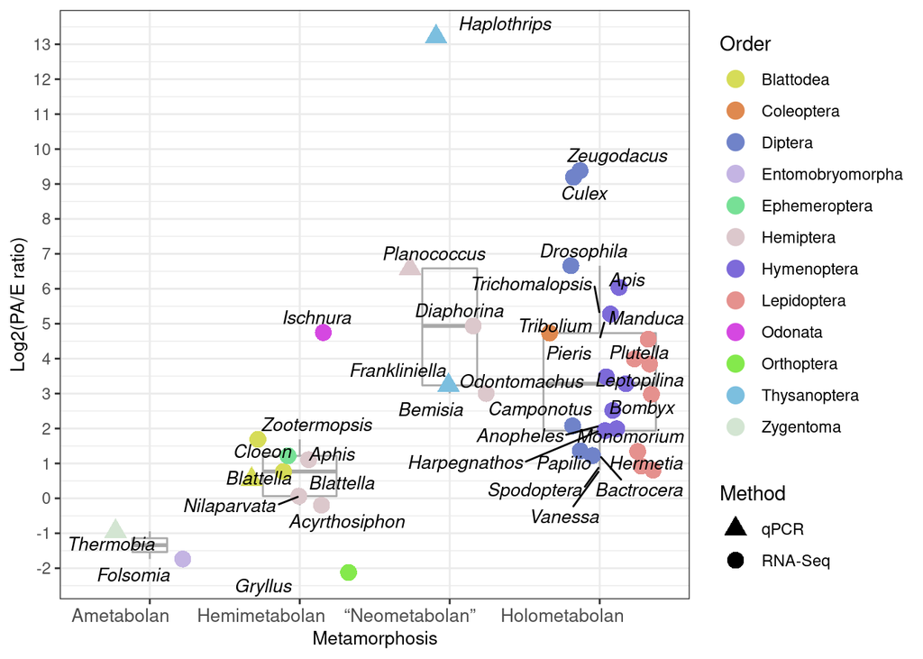

```r
ratio_peak_qPCR_neo_texonomy_val <- read_csv("/mnt/DATADISK/SRA_insects/all_sra_graphs/ratio_peak_qPCR_neo_texonomy_12.09.2022.csv")
ratio_peak_qPCR_neo_texonomy<-ratio_peak_qPCR_neo_texonomy_val

ratio_peak_qPCR_texonomy_plot_order_neo<-ratio_peak_qPCR_neo_texonomy%>%
  ggplot(., aes(x=reorder(Metamorphosis, as.numeric(plot)) ,color=Order, y= as.numeric(Log2ratio))) +  scale_y_continuous(breaks = seq(-2,14,by = 1))+
  geom_boxplot(varwidth = T, alpha =0.0001, color = "darkgray" ) +
     geom_point( position = position_jitterdodge(), size = 4,(aes(shape = factor(Method)))) +
    scale_shape_manual(values=c(17, 16))+

    geom_text_repel(aes(label =Species), size = 3.5 , colour = 'black', max.overlaps =100,fontface = "italic")+
    #geom_label_repel(aes(label = Organism),
                  #box.padding   = 0.35,
                  #point.padding = 0.5,
                  #segment.color = 'grey50',
                  #size = 3) +
    theme_bw()+

    theme(axis.text.x = element_text(hjust = .8, size=10))+
    labs(y="Log2(PA/E ratio)", x= "Metamorphosis",fill ="Legend", shape="Method", )+ #guides(color=FALSE) +
  theme(axis.title=element_text(size=10))+
    scale_color_manual(values =palette )

ratio_peak_qPCR_texonomy_plot_order_neo
```

# Calculate stats

## saparate data

```r
hemi<-ratio_peak_qPCR_neo_texonomy %>% filter(, Metamorphosis == "Hemimetabolan")
holo<-ratio_peak_qPCR_neo_texonomy %>% filter(, Metamorphosis == "Holometabolan")
neo<-ratio_peak_qPCR_neo_texonomy %>% filter(, Metamorphosis == "“Neometabolan”")
amet<-ratio_peak_qPCR_neo_texonomy %>% filter(, Metamorphosis == "Ametabolan")
```

## mean

```r
hemi_mean<-mean(hemi$Ratio)
holo_mean<-mean(holo$Ratio)
neo_mean<-mean(neo$Ratio)
amet_mean<-mean(amet$Ratio)

hemi_mean
```

```
## [1] 4.428379
```

```r
holo_mean
```

```
## [1] 76.0397
```

```r
neo_mean
```

```
## [1] 1928.791
```

```r
amet_mean
```

```
## [1] 0.4100713
```

#SEM

```r
library(plotrix)
hemi_SEM<-std.error(hemi$Ratio)
holo_SEM<-std.error(holo$Ratio)
neo_SEM<-std.error(neo$Ratio)
amet_SEM<-std.error(amet$Ratio)

hemi_SEM
```

```
## [1] 2.817031
```

```r
holo_SEM
```

```
## [1] 40.39048
```

```r
neo_SEM
```

```
## [1] 1892.87
```

```r
amet_SEM
```

```
## [1] 0.1099287
```

## wilcox test amet vs holo

```r
amet_holo<-ratio_peak_qPCR_neo_texonomy %>% filter(, Metamorphosis == "Holometabolan"| Metamorphosis=="Ametabolan")


test_wixlcox_ratio_a_holo_two_side <- wilcox.test(amet_holo$Ratio ~ amet_holo$Metamorphosis, paired = FALSE, alternative = "two.sided", mu = 0.0, exact = TRUE, correct = FALSE, conf.int = TRUE, conf.level = 0.99)
test_wixlcox_ratio_a_holo_two_side
```

```
##
##  Wilcoxon rank sum exact test
##
## data:  amet_holo$Ratio by amet_holo$Metamorphosis
## W = 0, p-value = 0.007905
## alternative hypothesis: true location shift is not equal to 0
## 99 percent confidence interval:
##  -666.735615   -1.230162
## sample estimates:
## difference in location
##               -9.32156
```

## wilcox test hemi vs amet

```r
amet_hemi<-ratio_peak_qPCR_neo_texonomy %>% filter(, Metamorphosis == "Hemimetabolan"| Metamorphosis=="Ametabolan")


test_wixlcox_ratio_a_hemi_two_side <- wilcox.test(amet_hemi$Ratio ~ amet_hemi$Metamorphosis, paired = FALSE, alternative = "two.sided", mu = 0.0, exact = TRUE, correct = FALSE, conf.int = TRUE, conf.level = 0.99)
test_wixlcox_ratio_a_hemi_two_side
```

```
##
##  Wilcoxon rank sum exact test
##
## data:  amet_hemi$Ratio by amet_hemi$Metamorphosis
## W = 2, p-value = 0.1455
## alternative hypothesis: true location shift is not equal to 0
## 96.36364 percent confidence interval:
##  -26.5417378   0.2901427
## sample estimates:
## difference in location
##              -1.293602
```

## wilcox test neo vs amet

```r
amet_neo<-ratio_peak_qPCR_neo_texonomy %>% filter(, Metamorphosis == "“Neometabolan”"| Metamorphosis=="Ametabolan")


test_wixlcox_ratio_a_neo_two_side <- wilcox.test(amet_neo$Ratio ~ amet_neo$Metamorphosis, paired = FALSE, alternative = "two.sided", mu = 0.0, exact = TRUE, correct = FALSE, conf.int = TRUE, conf.level = 0.99)
test_wixlcox_ratio_a_neo_two_side
```

```
##
##  Wilcoxon rank sum exact test
##
## data:  amet_neo$Ratio by amet_neo$Metamorphosis
## W = 10, p-value = 0.09524
## alternative hypothesis: true location shift is not equal to 0
## 90.47619 percent confidence interval:
##     7.48472 9499.69986
## sample estimates:
## difference in location
##               30.19285
```

## wilcox test hemi vs neo

```r
hemi_neo<-ratio_peak_qPCR_neo_texonomy %>% filter(, Metamorphosis == "Hemimetabolan"| Metamorphosis=="“Neometabolan”")


test_wixlcox_ratio_hemi_neo_two_side <- wilcox.test(hemi_neo$Ratio ~ hemi_neo$Metamorphosis, paired = FALSE, alternative = "two.sided", mu = 0.0, exact = TRUE, correct = FALSE, conf.int = TRUE, conf.level = 0.99)
test_wixlcox_ratio_hemi_neo_two_side
```

```
##
##  Wilcoxon rank sum exact test
##
## data:  hemi_neo$Ratio by hemi_neo$Metamorphosis
## W = 43, p-value = 0.003996
## alternative hypothesis: true location shift is not equal to 0
## 99 percent confidence interval:
##     4.780662 9498.539823
## sample estimates:
## difference in location
##               28.89925
```

```r
hemi_holo<-ratio_peak_qPCR_neo_texonomy %>% filter(, Metamorphosis == "Hemimetabolan"| Metamorphosis=="Holometabolan")


test_wixlcox_ratio_hemi_holo_two_side <- wilcox.test(hemi_holo$Ratio ~ hemi_holo$Metamorphosis, paired = FALSE, alternative = "two.sided", mu = 0.0, exact = TRUE, correct = FALSE, conf.int = TRUE, conf.level = 0.99)
test_wixlcox_ratio_hemi_holo_two_side
```

```
##
##  Wilcoxon rank sum exact test
##
## data:  hemi_holo$Ratio by hemi_holo$Metamorphosis
## W = 25, p-value = 0.0009591
## alternative hypothesis: true location shift is not equal to 0
## 99 percent confidence interval:
##  -37.7253857  -0.7558389
## sample estimates:
## difference in location
##              -6.844578
```

```r
neo_holo<-ratio_peak_qPCR_neo_texonomy %>% filter(, Metamorphosis == "“Neometabolan”"| Metamorphosis=="Holometabolan")


test_wixlcox_ratio_neo_holo_two_side <- wilcox.test(neo_holo$Ratio ~ neo_holo$Metamorphosis, paired = FALSE, alternative = "two.sided", mu = 0.0, exact = TRUE, correct = FALSE, conf.int = TRUE, conf.level = 0.99)
test_wixlcox_ratio_neo_holo_two_side
```

```
##
##  Wilcoxon rank sum exact test
##
## data:  neo_holo$Ratio by neo_holo$Metamorphosis
## W = 75, p-value = 0.157
## alternative hypothesis: true location shift is not equal to 0
## 99 percent confidence interval:
##   -30.76616 9476.45726
## sample estimates:
## difference in location
##               14.67927
```